# Signal K Server

User guide, version 2.33.0 — github.com/SignalK/signalk-server

# Introduction

Signal K Server is software designed to be deployed on a vessel to act as a central hub which:

1. Collects data from devices and sensors on board
2. Aggregates and exposes it using the *[Signal K Data Standard](https://signalk.org/specification/latest/)*
3. Exposes the collected data via REST APIs and websocket protocols over a standard WiFi, LAN or Internet connection.

Through implementation of the *[Signal K Data Standard](https://signalk.org/specification/latest/)*, it enables data exchange between NMEA0183, NMEA2000 and other marine protocols facilitating two way communication between the various onboard systems. In addition it can also act as data hub for additional sensors ensuring their data appears within the single data model. *(Visit the [Signal K SensESP project](https://github.com/SignalK/SensESP) for ESP32 for details.).*

Data is made available to client applications / connections in JSON format making it widely accessible to Apps on phone / tablet devices and web applications.

Signal K Server is also extensible, providing a plugin framework which allows developers to create solutions that integrate and extend its capabilities. These solutions can be published to **npmjs** and installed via the **App Store** in the server's web-based user interface.

[figure not shown]

# Installation

Signal K Server is a [NodeJS](https://nodejs.org/en) application which can run on nearly any computer and operating system, including Window, Linux, and macOS.

Currently the most cost effective, powerful and best supported hardware platform for a Signal K server is the [Raspberry Pi](https://www.raspberrypi.com). Any Raspberry Pi (even the very first model) can be used but for best performance we recommend Raspberry Pi 4 model B or 5. If you don't have a Raspberry Pi, any old laptop or computer you have sitting around would make a good initial test platform, although for permanent use on a yacht, more power efficient hardware like a Raspberry Pi is strongly recommended.

## Ready-made options

You do not have to install Signal K Server yourself. Several commercially available devices ship with it inside, and several prebuilt Raspberry Pi images install it for you. Both are listed under [How to get Signal K Server?](https://github.com/SignalK/signalk-server#how-to-get-signal-k-server) in the project README. If one of them suits your boat, you do not need the instructions below.

## Prerequisites

Note

Signal K server requires [NodeJS](https://nodejs.org) version >= 22 (version 24 recommended) be installed on the target system.

## Getting Started

- Installing on Raspberry Pi
- [Installing on Windows](https://github.com/SignalK/signalk-server-windows)
- Installing from NPM
- Installing from Docker
- Installing from Source

# Installing on Raspberry Pi

Installation of Signal K server consists of the following steps:

1. Install the tools and libraries required to run the Signal K server (the dependencies)
2. Install a Signal K Server to process the Signal K data
3. Run the Setup script.

**Important:** If you are updating a Signal K server installation, especially if upgrading an installed version <= 1.40.0, please check here first.

Tip

You can skip these steps entirely by flashing a prebuilt image that already includes Signal K Server. See [How to get Signal K Server?](https://github.com/SignalK/signalk-server#how-to-get-signal-k-server) for the available images.

## Prerequisites:

**64-bit** Raspberry Pi OS is installed on the device (Pi 3, 4 or 5 required). Node.js 24 does not support 32-bit ARM (armv7).

For instructions on how to install the operating system see [Raspberry Pi Getting Started](https://www.raspberrypi.org/documentation/computers/getting-started.html#setting-up-your-raspberry-pi).

*Note: It is also possible to perform a "headless install" using `Raspberry Pi OS Lite` since the GUI for Signal K is browser based.*

Once the OS installation has been completed, you are ready to commence.

## Install the Dependencies

1. Log in to the RPi Desktop and open a terminal.
2. Update the list of install packages.

   ```
   sudo apt update
   ```

3. Install NodeJS 24 and npm.

   Follow [instructions for Ubuntu and Debian based distributions like Raspberry Pi OS at NodeSource Distributions](https://github.com/nodesource/distributions#installation-instructions).
4. Ensure that we're using the latest version of npm.

   ```
   sudo npm install -g npm@latest
   ```

   Use the following command to check the versions of NodeJS and npm installed.

   ```
   node -v && npm -v
   ```

   Ensure the reported versions are equal to or greater than `v24.0.0, 11.0.0` respectively.
5. Install a Bonjour (mDNS) service for Linux called Avahi, which allows Apps and other network devices to Discover the Signal K server.

   ```
   sudo apt install libnss-mdns avahi-utils libavahi-compat-libdnssd-dev
   ```

## Install Signal K Server

```
sudo npm install -g signalk-server
```

You can test that installation was successful by starting the server using some sample data.

```
signalk-server --sample-nmea0183-data
```

You should see the terminal output "signalk-server running at 0.0.0.0:3000" as shown below...

```
signalk-server --sample-nmea0183-data
Using sample data from /usr/lib/node_modules/signalk-server/samples/plaka.log
signalk-server running at 0.0.0.0:3000
```

The Signal K Node Server is now reading and publishing sample NMEA0183 data from the specified file.

Using a Web browser enter the following URL: `http://127.0.0.1:3000/signalk` which should display the following information indicating the server is up and running.

```json
{
    "endpoints":{
        "v1":{
            "version":"2.0.0",
            "signalk-http":"http://127.0.0.1:3000/signalk/v1/api/",
            "signalk-ws":"ws://127.0.0.1:3000/signalk/v1/stream",
            "signalk-tcp":"tcp://127.0.0.1:3858"
        }
    },
    "server":{
        "id":"signalk-server-node",
        "version":"2.0.0"
    }
}
```

## Run the Setup Script

Now that you have Signal K server installed, you will want to generate a settings file for your vessel and configure your RPi to start the server automatically. To do this run the setup script by entering the following command and follow the prompts.

```
sudo signalk-server-setup
```

You can re-run this command at any time in the future to change the settings.

*Note: The setup script will enable security which will require you to `Login` from the Admin UI. Clicking `Login` for the first time will prompt you to create a user and password.*

Signal K server will now be started automatically when your RPi boots up.

If you want to temporarily stop the Signal K server, you can do so by entering the following commands:

```
sudo systemctl stop signalk.service
sudo systemctl stop signalk.socket
```

To start Signal K server again enter the following commands:

```
sudo systemctl start signalk.service
sudo systemctl start signalk.socket
```

To stop Signal K server from starting automatically enter the following commands:

```
sudo systemctl disable signalk.service
sudo systemctl disable signalk.socket
```

You are ready to now **configure** your installation and connect data from devices on your boat.

# Installing from NPM

Signal K Server can be installed directly using NPM.

## Linux / macOS

```bash
sudo npm install -g signalk-server
```

Once installation is complete, enter the following in a terminal window, to generate a settings file and configure the server to start automatically:

```bash
sudo signalk-server-setup
```

If you choose not to use `signalk-server-setup` you can start the server by entering the following in a terminal window:

```bash
signalk-server
```

You are ready to now **configure** your installation and connect data from devices on your boat.

## Windows

See [Installing on Windows](https://github.com/SignalK/signalk-server-windows).

# Installing from Docker

Signal K Server is available as a Docker image on *Docker Hub* and *cr.signalk.io/signalk/signalk-server*.

To simply run a Signal K Server with some sample data on a device with docker installed, enter the following into a terminal:

```bash
docker run -it --rm --publish 3000:3000 signalk/signalk-server
```

This will start an instance of Signal K Server on port 3000 which you can then access via the web based Admin UI by pointing your web browser at `http://localhost:3000`.

If you are wanting to use docker to deploy Signal K Server on your vessel you will need to:

1. Specify a location to persist the server's configuration so it is not lost between restarts
2. Run the instance as a background process

*Example: Run as background process and store server configuration in the current folder:*

```bash
docker run -d --init --name signalk-server -p 3000:3000 -v $(pwd):/home/node/.signalk signalk/signalk-server
```

You are ready to now **configure** your installation and connect data from devices on your boat.

# Installing from source

Installation from the GitHub repository is useful when developing plugins and components.

To do this enter the following commands in a terminal window:

```bash
# Copy the files to your device
git clone https://github.com/SignalK/signalk-server.git

# change to the folder containing the downloaded files
cd signalk-server

# install the dependencies
npm install

# build all packages in the repository
npm run build:all
```

To start Signal K Server with a sample configuration file and some sample data, enter the following into a terminal: *To use NMEA0183 sample data:*

```bash
bin/nmea-from-file
```

*To use NMEA2000 sample data:*

```bash
bin/n2k-from-file
```

The server will start playing back data from the specified sample file that can be viewed using the *Data Browser* in the Admin UI *(`http://localhost:3000`)* or via REST API / websocket connection.

# Updating your Installation

Signal K Server is frequently updated to introduce new features and fix issues that have been reported. Sometime these updates require that NodeJS or other supporting software on your device to be upgraded to support the new functionality.

Additionally your device's operating system are constantly evolving to address security issues as well as providing new capabilities.

Regularly updating your installation will reduce both the volume of data download and the time taken to complete the process. Connecting your device to a network with good broadband speed before performing an update is recommended.

Updates fall into four categories:

1. Device Operating system (e.g. RaspberryPi OS)
2. NodeJS / NPM
3. Signal K Server
4. Signal K WebApps and Plugins

## Update Device Operating System

Instructions will vary depending on your device but for linux based systems such as the Raspberry Pi the following instructions are used to update the OS.

From a terminal window enter the following commands:

```bash
sudo apt update

sudo apt dist-upgrade
```

If you have not performed an update for a while these commands may take a while to complete, just be patient and make sure everything completes correctly.

After the process has completed `restart` your device.

## Update NodeJS and NPM

To ensure the version of NodeJS on your device is supported by Signal K Server *(see prerequisites)*, check the installed version by entering the following in a terminal window:

```bash
node -v

# example response
v18.17.0
```

If the version of NodeJS displayed is lower than the version supported by Signal K Server then you can update it with the following command:

```bash
sudo apt upgrade nodejs
```

It is also recommended to update the version of the Node Package Manager (NPM).

```bash
sudo npm install -g npm@latest
```

## Update Signal K Server

When an update is available for Signal K Server a visual indication is displayed in the Admin UI.

**Important!** Before updating please ensure the version of NodeJS on your device is supported by Signal K Server.

**If you are updating from Signal K Server version v1.40.0 or earlier please [read this first](https://github.com/SignalK/signalk-server/wiki/Installing-and-Updating-Node.js) before proceeding.**

Click on *Server -> Update* to display information about the new version.

[figure not shown]

Click **Update** to start the installation.

After the installation is complete, click **Restart** to launch the updated Signal K Server.

### WebApps and Plugins

After updating Signal K Server some plugins and WebApps may also need to be updated.

The AppStore is where WebApps and Plugins can be installed, removed or updated. Those with an update available will be listed in *Appstore -> Updates* in the Admin UI.

Clicking on the *download cloud* button next to the WebApp / Plugin you wish to update.

After all installations have been completed, click **Restart** to activate the updated WebApps and Plugins.

# Runtime Environment & Options

Signal K Server provides the following command line options and environment variables to configure your implementation.

## Command line options

[output not shown]

## Environment variables

[output not shown]

## Settings file options

The following options can be set in `settings.json` or via the server settings API.

[output not shown]

# Configuring Signal K Server

Signal K Server provides an Admin UI to allow you to easily configure your installation.

Open the Admin UI using a web browser on the device where Signal K server is installed (if the defaults have not been changed) by navigating to `http://localhost:3000`.

## Create an Admin account

It is considered good practise to enable security and create an administrator account to controll access to your server and protect your data.

If you ran the `signalk-server-setup` script, security will be enabled and you will be presented with a login screen when accessing the Admin UI.

If the login screen is not displayed, click `Login` *(top right of screen)* to display the prompt to create a user and password.

Alternatively, from the menu select *Security -> Users* and then:

1. Click **Add**
2. Enter a **user id**
3. Enter a **password** and confirm it
4. In **Permissions** select **Admin**
5. Click **Apply**.

After creating the account, the server needs to be restarted.

How you restart the server will depend on the installation type *(i.e. installed from NPM, embedded on a commercial device, etc)*. Power cycling the device that Signal K Server is always an option.

## Set up data connections

To get data into Signal K server you will need to configure one or more data connections via the *Server -> Data Connections* menu option.

From this screen you can add connections for various data types including:

- NMEA2000
- NMEA0183
- Signal K
- SeaTalk
- File Stream

The options presented will vary based on the data type chosen.

*NMEA2000*: The processing of NMEA2000 PGNs is done by n2k-signalk via canboatjs.

Please refer to the [Canboat PGN database](https://canboat.github.io/canboat/canboat.html) to see what PGNs are supported.

Once your NMEA 2000 devices are connected, you can view and manage them from *Data -> Source Discovery* in the Admin UI. See NMEA 2000 Device Management for details on device discovery, instance editing, and conflict detection.

*NMEA0183*: The processing of NMEA0183 sentences is done by [nmea0183-signalk](https://github.com/SignalK/signalk-parser-nmea0183)

### NMEA 0183 Options

- *Suppress nmea0183 event* - All incoming NMEA0183 data is made available over TCP on port 10110 by default. This happens by incoming data being emitted as *nmea0183* events. Selecting this option will prevent data from this connection appearing on the NEMA0183 TCP service.
- *Input Event* - By default, data received on this connection will cause the nmea0183 event to be emitted. In order to distinguish input from this connection from other NMEA 0183 connections, enter an input event name which will be emitted (in addition to the nmea0183 event) when data is received on this connection.
- *Validate checksum* - Usually [NMEA 0183 sentences](https://en.wikipedia.org/wiki/NMEA_0183) contain a checksum that can be used to check that the data is not garbled so that erroneous data is discarded. However some data sources do not include the checksum or it is simply wrong. Unchecking this option will disable validating the checksum.
- *Append Checksum* - See previous point. Some data sources do not include a checksum, but for example a mobile app you are using may require them. Activating this option will add checksums to the data.
- *Remove NULL characters* - Some data sources include superfluous NULL characters in the input data stream, making the data invalid for consumption. This option will remove the NULL characters. It causes additional processing, so not on by default.
- *Ignored Sentences* - NMEA0183 sentences to throw away from the input data. Sometimes you may want to ignore certain sentences from a connection, because the data is invalid or missing or just not needed.
- *Override timestamps* - NMEA0183 data may include timestamps in tag blocks. These may be off or when playing back captured data you may want to ignore the data and override them with current time when converting to Signal K.

**Connection type "File Stream"**

Sample files are available which can be set up as input for the server.

Use below command to get the path to a NMEA 2000 file with navigation data and AIS targets.

```
sudo find / -name "aava-n2k.data"
```

Set up according to picture.

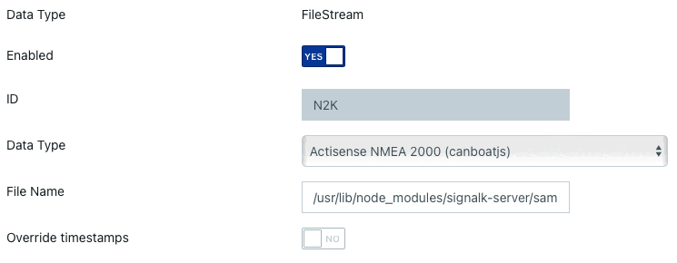

To get the path for the sample file, data type NMEA 0183, use below command.

```
sudo find / -name "plaka.log"
```

## Exploring and Managing Data

The *Data* menu provides tools for viewing, inspecting, and managing your Signal K data:

- **Data Browser** — Browse all Signal K data paths in real time with values, sources, and timestamps.
- **Meta Data** — View and edit Signal K metadata (units, descriptions, display names, zones) for any path.
- **Source Discovery** — View all data sources connected to the server. For NMEA 2000, this shows a detailed table of every device on the bus with manufacturer, model, and instance information. Includes instance conflict detection. See NMEA 2000 Device Management for details.
- **Source Priority** *(admin only)* — Configure which source the server prefers when multiple sources provide the same data path, on a per-path basis. See Source Priority for details.
- **Unit Preferences** — Configure automatic unit conversions (e.g. Kelvin to Celsius, m/s to knots) for the admin UI and WebSocket subscribers.
- **Data Fiddler** *(admin only)* — Manually set Signal K path values for testing.
- **Data Connections** *(admin only)* — Configure data connections (NMEA 2000, NMEA 0183, etc.). See the Set up data connections section above.

## Install Plugins and Webapps

Signal K server functionality can be extended through the use of plugins and webapps.

Plugins typically extend data acquisition, data processing or enable operations (i.e. protocol conversion, etc).

Webapps provide a user interface to view / interact with data or perform operations enabling full featured solutions such as a Chartplotter.

To install, update or remove plugins and webapps select *Appstore* from the menu.

Select:

- `Installed` to view a list of plugins and webapps currently installed.
- `Updates` to view a list of plugins and webapps that have updates available.
- `Available` to view a list of available plugins and webapps that can be filtered by categry.

The entries displayed with a blue icon are webapps, those with a green icon are plugins and those with both blue and green icons are plugins with a webapp providing a user interface.

*Note: An internet connection is required for Signal K Server to list, install and update AppStore listings.*

To install, click the `download` icon on the right hand side of the entry.

To view a list of Plugins and Webapps directly from the NPM registry select the links below.

- [Plugins](https://www.npmjs.com/search?q=keywords%3Asignalk-node-server-plugin)
- [Webapps](https://www.npmjs.com/search?q=keywords:signalk-webapp)

*Note: A restart of the Signal K server is required after plugins or webapps have been installed or updated.*

Click the *Restart* button at the top right of the screen to restart the server.

After the server has restarted, the installed plugin(s) can be configued by selecting *Server -> Plugin Config* menu entry.

## The Webapps page

Installed webapps are launched from the *Webapps* page of the Admin UI.

The sort selector at the top right of the list offers three orders:

- `A-Z` — alphabetical, by display name.
- `Custom order` — arrange the webapps yourself by dragging the grip handle at the top right of each card (works with mouse and touch). Newly installed webapps are appended at the end of your order.
- `Last used` — most recently launched webapps first, followed by the webapps you have not launched yet in alphabetical order.

The last selected order becomes your standard view and is restored on your next visit. It is remembered per browser; on servers with security enabled it is additionally stored per user, so it follows your login across devices.

## Trouble shooting and the Server Log

If things are not working as expected after installing a plugin or webapp, select *Server -> Server Log* to view the server's log. If the errors logged there are not providing the information required, you can enable debugging for individual components and plugins by toggling the switch to activate them.

Enabling the `Remember debug setting` ensure your selections are remebered after a server restart.

## Landing page

When you access the Signal K server on a web browser you will be redirected to the Admin webapp as the default `landing page`. You can replace this default with your choice by adding the property `landingPage` in your `settings.json`. For example you can redirect the user to Kip or Freeboard.

## Add your Logo

You can change the logo image displayed at the top left of the Admin UI screen. To do this, add an SVG file named `logo.svg` in the settings directory *(default: $HOME/.signalk/)*.

# Seatalk Connections

The Signal K Server supports a variety of data connection types including *Seatalk (GPIO)* which provides the ability to receive Raymarine Seatalk 1 (ST1) data, via simple DIY hardware connected to a Raspberry Pi GPIO, and convert it to Signal K deltas. This information can then be forwarded by the Signal K Server to a NMEA 0183 or NMEA 2000 network using appropriate hardware and plugins.

A guide to SeaTalk can be found [here](http://boatprojects.blogspot.com/2012/12/beginners-guide-to-raymarines-seatalk.html).

## Hardware

Using an optocoupler as the hardware interface is recommended as it creates electrical isolation from hazardous voltages and avoids ground loops.

The circuit below uses the [PC817 optocoupler board](https://www.amazon.com/ARCELI-Optocoupler-Isolation-Converter-Photoelectric/dp/B07M78S8LB/ref=sr_1_2?dchild=1&keywords=pc817+optocoupler&qid=1593516071&sr=8-2) but any equivlent product can be used. The LED in the circuit will flicker when there is ST1 traffic.

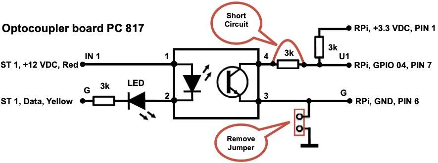

If you are building the interface yourself use the below circuit instead. If you don't want any flickering just drop the LED at the input.

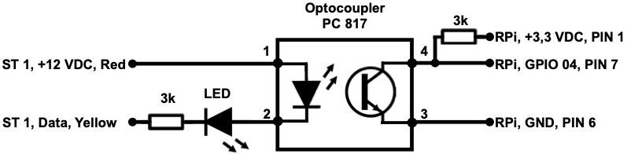

A simpler, non-electrically isolated, solution is detailed below, using a low signal NPN transistor which inverts and shifts the voltage from 12V DC to 3.3V DC.

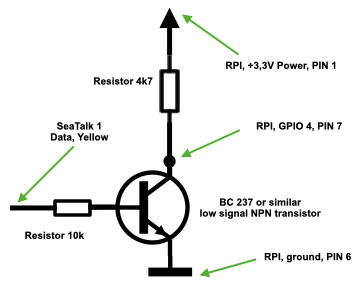

If you do not want to build your own circuit, you can get a **MacArthur HAT** and simply connect it to your Seatalk 1 network [following the manual](https://macarthur-hat-documentation.readthedocs.io/en/latest/seatalk.html). If you also use OpenPlotter with this HAT, all the software will be installed and ready to go.

[figure not shown]

## Software

Before setting up the data connection on Signal K Server, you may need to install some associated Python libraries on your system. Here you have two options: gpiod library (**Raspberry Pi 3, 4 and 5 models**) or pigpio library (**Raspberry Pi 3 and 4 models**).

### gpiod (recommended)

Both versions of this library 1.x.x (Debian package) and 2.x.x (Pip package) are supported. It is possible that your system already has one of the two versions of this library installed and some program is already using it, so before installing it we will check if we already have one.

Type this in a terminal:

```
python -m pydoc gpiod | tail
```

If gpiod appears as installed, simply do nothing and go directly to the *Data Connection* section.

If it is not installed, type this in a terminal to install the latest version from pip:

```
sudo pip3 install gpiod
```

Since Debian 12 (Bookworm) and Ubuntu 24 (Noble), pip packages need to be installed in virtual environments, but we need this library to be installed at the system level, so on these systems we need to type this instead:

```
sudo pip3 install gpiod --break-system-packages
```

Pip will complain that the package is being installed in a non-virtual environment, but you can ignore the warning because it has not been detected to break any system packages.

### pigpio

*Inspired by [Read SeaTalk1 from the Raspberry Pi GPIO using pigpio](https://github.com/Thomas-GeDaD/Seatalk1-Raspi-reader).*

Open a terminal and enter the following:

1. Update the package manifest

```
    sudo apt-get update
```

2. Install the software

```
    sudo apt-get install pigpio python-pigpio python3-pigpio
```

3. Enable and start the *pigpio* [daemon](http://abyz.me.uk/rpi/pigpio/) which handles the data connection.

```
    sudo systemctl enable pigpiod && sudo systemctl restart  pigpiod
```

4. Check the _pigpio_service is running

```
    sudo systemctl status pigpiod
```

*Note: The _pigpio* deamon by default provides a socket interface on port 8888, which may conflict with other software running on your Raspberry Pi. To have the socket interface use another port you will need to change the [pigpiod.service file](http://abyz.me.uk/rpi/pigpio/pigpiod.html) using the [Python program](http://abyz.me.uk/rpi/pigpio/python.html#pigpio.pi) with the -p option._

### Data Connection

With the required software installed, you can now add a new data connection using the Signal K Server Admin UI.

*Example Data Connection:*

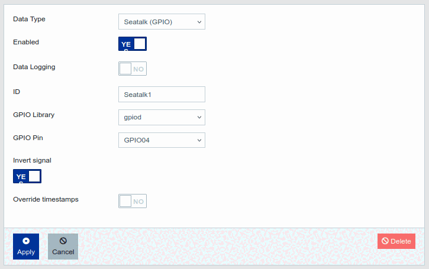

- Select *Server -> Data Connections* from the main menu.
- Click the **Add** button to create a new connection.
- Select **Seatalk (GPIO)** in the *Data Type* dropdown list.
- Set the *Enabled* to **Yes**.
- Enter an *ID* *(e.g. Seatalk1)*.
- In *GPIO Library*, select the software that is installed on your system as we have seen in the previous section.
- In *GPIO Pin*, select one of the green GPIO pins from those pictured below *(this will be the pin to which you connect your hardware e.g. GPIO04).*

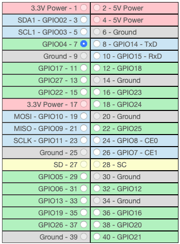

### Viewing Received Data

Once the server has restarted, confirm that data is being received from the ST1 connection by using the *Data Browser* in the Admin UI .

The data received via the Seatalk connection will be displayed in the Data Browser with a source value that contains the *ID* you provided when setting up the connection.

If there is no data displayed in the Data Browser from the Seatalk connection, you can check if there is data available at the selected GPIO using these utilities:

gpiod: https://gist.github.com/astuder/c319cf955f6d651350222d36065981b3

pigpio: https://raw.githubusercontent.com/MatsA/seatalk1-to-NMEA0183/master/STALK_read.py

If the display shows ST1 sentences being received at the GPIO pin then review your data connection settings.

# NMEA Connections

Most equipment on boats use NMEA 0183, NMEA 2000, or other proprietary interfaces to communicate with each other. A lot of work has been done within the Signal K community to convert these different data formats in to Signal K.

## NMEA 0183

There are a number of NMEA to USB adaptors around, like [Actisense](http://www.actisense.com/product/usg-2/) and [Digital Yacht](http://digitalyacht.co.uk/product/usb-nmea-adaptor/), which allow bi-directional transfer of the NMEA 0183 Serial data (electrically similar to RS-422) and convert it in to a USB virtual COM Port when plugged in to the Signal K server.

In Linux the virtual COM Port will be seen as a device called `/dev/ttyUSB0` (the number could be different if there are multiple USB-to-serial adapters connected). Linux assigns these device names automatically when the device is connected, so it could change. If you want to ensure that the device always has the same name, you will need to write a UDEV rule to specify an alias. See creating UDEV rules for details.

To verify that you have a working connection, you can use picocom or another terminal emulator to see if you are receiving data. The default baud rate for standard NMEA 0183 is 4800, whilst AIS and multiplexers use NMEA 0183(HS) at the "High Speed" 38400 baud rate.

```
$ picocom -b 4800 /dev/ttyUSB0
```

You should see NMEA 0183 sentences scrolling off the screen. To exit picocom press `Ctrl-a` followed by `Ctrl-x`.

Once your NMEA 0183 connection is working, you can set up data connections the Signal K server to read the data.

## NMEA 2000

NMEA 2000 support in Signal K is provided by canboatjs, which is a library that can read and write NMEA 2000 data. See the [list of supported devices from canboatjs](https://github.com/canboat/canboatjs#supported-devices) for details of hardware that can be used to connect to NMEA 2000 networks.

Directions for configuring your hardware will vary by device, so consult the documentation for your hardware for details. Once you have your hardware connected and configured, you can use the `candump` utility from the `can-utils` package to verify that you are receiving NMEA 2000 data.

```bash
candump can0
```

You should see NMEA 2000 data scrolling off the screen. Press `Ctrl-c` to exit candump.

After confirming you have NMEA data, you can set up data connections the Signal K server to read the data.

Once your data connection is configured, see NMEA 2000 Device Management for discovering devices, managing instance numbers, and resolving instance conflicts.

# NMEA 2000 Device Management

Signal K Server can discover and configure NMEA 2000 devices directly from the Admin UI under *Data → Source Discovery*. This includes identifying devices on the bus, viewing their product information, detecting instance conflicts, and remotely changing device, battery and DC instances — without additional hardware like an Actisense NGT-1.

## Source Discovery

Source Discovery lists every data source the server has seen. For an NMEA 2000 connection it shows one row per device with manufacturer, model, software version, instance numbers and installation labels.

The server identifies devices by **CAN Name**, the 64-bit unique identifier from the ISO Address Claim (PGN 60928). The CAN Name is stable across address changes — when a device drops off and rejoins the bus it can take a different N2K address, but its CAN Name does not change. Two devices of the same model still get different CAN Names because the ISO Address Claim includes a per-device unique number.

If you connect over a bidirectional gateway (e.g. Yacht Devices YDWG-02 over TCP, or a CAN adapter), pressing **Discover N2K Devices** asks each device for its Product Information so manufacturer/model fields are populated. UDP-only gateways are receive-only and cannot be used for discovery.

### Known limitation: source attribution over Yacht Devices UDP

When the bus is fed via a Yacht Devices YDEN-02 (or similar) over UDP, observed bus frames can occasionally be attributed to the gateway's own N2K address instead of the originating device. The same setup over TCP, or a directly attached CAN adapter, does not show this — both the canhat / Actisense direct path and the YDWG-02 TCP path produce a clean source list.

The effect: a device like an IPG100 that physically does not transmit, say, PGN 127258 may nonetheless appear as a source for `navigation.magneticVariation` in Source Discovery and inside priority groups. Trash the row from the group when it goes Offline (see Source Priorities), or — preferably — switch the connection to TCP so the wrong attribution does not happen in the first place.

You can give any device a custom alias via the pencil icon next to its label — useful when two identical devices need to be told apart (e.g. "Bow GPS" vs "Stern GPS").

## Instance Concepts

NMEA 2000 uses several different instance numbers to distinguish between sensors of the same kind. Knowing which one to change matters: editing the wrong one usually has no effect, and on Victron equipment editing the wrong one can break parallel-charging coordination.

### Device Instance (in PGN 60928, ISO Address Claim)

The **Device Instance** identifies a physical device on the bus. It comprises two parts that can be edited together or independently:

- **Data Instance** ("Device Instance Lower") — used by some classes of device to distinguish sensor readings from the same device.
- **System Instance** ("Device Instance Upper") — groups devices into subsystems.

### Battery Instance (in PGN 127508, Battery Status)

The **Battery Instance** identifies which battery bank a measurement belongs to. It is independent of the Device Instance — a single charger can report multiple banks.

The common multi-MPPT problem: when several Victron solar chargers report through one Victron GX gateway they all default to Battery Instance 0, so MFDs and Signal K cannot tell their readings apart. Assigning unique Battery Instance values to each charger is the fix.

### DC Instance (in PGN 127506, DC Detailed Status)

The **DC Instance** plays the same role for `127506` (DC voltage/current measurements) that Battery Instance plays for `127508`.

## Editing Instances

Signal K Server can change instance numbers and installation descriptions remotely by sending PGN 126208 (NMEA Command Group Function). Open a device row, edit the field, and submit — the new value is broadcast to the device. The Admin UI exposes only the fields that have a defined PGN 126208 mapping.

Not every device implements PGN 126208. The protocol does not define an acknowledgement, so a non-supporting device silently ignores the command. If the value does not change after a few seconds, the device probably does not accept that field over the bus.

PGN 126998 (Configuration Information) carries two free-text fields. The first is normally used for a location label ("Port Engine Room", "Bow Thruster"). The second is used by some manufacturers — Yacht Devices in particular — for `YD:`-prefixed configuration commands; consult the manufacturer documentation before writing to it.

**Manufacturer caveats.** Victron equipment uses Device Instance for internal synchronization between chargers; changing it on a live system can break parallel charging or ESS coordination. The Admin UI surfaces a Victron-specific warning at the edit point. For other manufacturers a generic "check your device documentation first" reminder is shown.

## Instance Conflict Detection

When two devices on the bus share the same Device Instance and transmit overlapping data PGNs, instruments downstream may not be able to tell their readings apart. Source Discovery detects these conflicts and surfaces them via:

- A warning badge on the sidebar's *Data* entry.
- A conflict alert panel at the top of the Source Discovery page.
- Per-PGN highlighting inside an expanded device row, marking the PGNs that overlap.

Protocol PGNs that every device sends (Address Claim, Product Information, etc.) and temperature/humidity PGNs where the data source field already distinguishes readings are excluded from conflict counting.

# Source Priority

When multiple data sources publish the same Signal K paths (e.g. two GPS devices both providing `navigation.position`), Signal K Server needs to decide which source to use. The Source Priority system organises sources into **Priority Groups** and lets you set a ranking per group, with optional per-path overrides.

These features are available in the Admin UI under *Data -> Source Priority*.

## Priority Groups

A **Priority Group** is a set of sources that share at least one published path. Groups are derived automatically: whenever two sources publish the same path, they land in the same group. Chains extend transitively — if A and B share a path and B and C share another, A, B and C are all in the same group.

Typical groups you will see on a real boat:

- A **GPS group**: all devices publishing `navigation.position`, `navigation.courseOverGroundTrue`, `navigation.speedOverGround`, etc.
- A **wind group**: masthead transducer, AIS wind reports, derived-data plugin output, etc.
- A **depth group**, **heading group**, and so on.

For each group you set a **source ranking** by dragging the sources into order. The top source is preferred across every shared path in the group, the second source is the first backup, and so on. In most installations, ranking groups is all you need — per-path tweaks are the exception, not the rule.

### Sidebar Badge

The sidebar shows a yellow warning badge on the *Data* menu item while any group lacks a saved ranking. The number reflects how many groups are still unranked; it drops to zero once every group has an order saved.

## How Rankings Work

Within a group, the top-ranked source is **preferred** — while it is publishing data, its values always win on every shared path. Every other rank has a **Fallback after** value: the number of milliseconds the **currently-winning** source must be silent before that rank is allowed to take over.

[figure not shown]

The important subtlety: each rank's timer is measured against whichever source is **currently winning**, not against rank 1.

- When the preferred source goes silent, rank 2's Fallback clock starts.
- If and when rank 2 takes over, it becomes the winner. From that moment, rank 3's Fallback clock starts ticking against rank 2, not against rank 1.
- So if rank 2 keeps actively sending after taking over, rank 3 never wins — the chain cascades one step at a time.

The preferred source has no Fallback value because nothing ranks higher. When it returns after any silence, it immediately resumes winning — the backups do not "hold" their position.

### A Worked Example

Three GPS devices on the boat all publish `navigation.position` and related paths. Signal K places them in one group. In the Admin UI the sources appear with human-readable labels; the underlying `$source` values are CAN Names:

| Rank | Shown as | `$source` (CAN Name) | Fallback after |
| --- | --- | --- | --- |
| 1 | Furuno (`can0.c0788c00e7e04312`) | `can0.c0788c00e7e04312` | *preferred* |
| 2 | Garmin (`can0.c0328400e7e00a86`) | `can0.c0328400e7e00a86` | `15000` (15 s) |
| 3 | serial0.GP | `serial0.GP` | `30000` (30 s) |

Scenarios:

- **Furuno is healthy:** only Furuno values reach subscribers on every shared GPS path. Garmin and serial0.GP are ignored even though they publish continuously.
- **Furuno unplugged, Garmin healthy:** after 15 s of Furuno silence, Garmin takes over and keeps winning as long as it keeps publishing. serial0.GP is still ignored — its 30 s clock is measured against Garmin, but Garmin is never silent.
- **Furuno unplugged AND Garmin unplugged:** after 15 s of Furuno silence, Garmin takes over. 30 s later (measured from Garmin's last value), serial0.GP takes over.
- **Furuno returns:** it immediately wins again, regardless of which backup was winning.

## Path-Level Overrides

A path-level override tells Signal K to use a **different** ranking for one specific path than the group's ranking would imply. Overrides sit inside the group card — they are the exception, not the rule.

A common example: two GPS units land in one group, Furuno is ranked first overall, but the Garmin has a better magnetic-variation (WMM) model. An override on `navigation.magneticVariation` prefers Garmin on that one path while every other shared path still prefers Furuno.

### Disabling a Source on a Path

Inside an override, unchecking **Enabled** on a row blocks that source on this path entirely, no matter how silent the others become. The disabled row stays visible in the list so it can be re-enabled later without re-ordering.

### Ungrouped Overrides

If a path only has a single publisher today, no group is created for it. You can still add an ungrouped override for that path — useful for pre-configuring ranking before a second source arrives, or for disabling a plugin-only path.

## Sources Not Listed

Data from a source that is not listed in the priority table for a path is held back until every listed source has been silent for a safety window. This is so an unconfigured new device on the bus doesn't suddenly hijack a path you have not thought about. The window's default is set conservatively; you can tune it via the Admin UI's *Default Fallback after* control.

## What is Not Filtered

`notifications.*` paths bypass source priority entirely — every source's notifications are delivered unchanged. Notifications are events, not measurements, so suppressing one source's alarm because another source is "preferred" is never the right behaviour.

Raw NMEA 0183 sentences forwarded to the NMEA 0183 TCP server on port 10110 are not filtered either. See NMEA 0183 Output.

All source data is preserved in the server's data model regardless of priority configuration. Priority only affects which source's values are delivered to subscribers by default. See Source Priority in the Data Browser for how to view every source's data.

## NMEA 0183 Output

Sentences received on NMEA 0183 connections are forwarded as raw NMEA 0183 to the NMEA 0183 TCP server on port 10110, independently of their conversion to Signal K. Source priority works on the converted Signal K data, so it never applies to this pass-through: with two GPS receivers connected, a client on port 10110 receives the sentences of both.

Therefore outputs that take source priorities into account need to be built from the Signal K data rather than passed through. The *signalk-to-nmea0183* plugin generates its sentences from the priority-filtered values, so its output follows the preferred source and the fallback behaviour described in How Rankings Work. For that output to be the only copy of the data on port 10110, the pass-through of the original sentences is switched off on the connections that carry them, see NMEA 0183 Options.

## Source Priority in the Data Browser

The Data Browser (*Data -> Browser*) has a **Sources** dropdown that controls which source's data is displayed:

- **Priority filtered** (default): shows only the preferred source's data for each path, respecting your priority configuration.
- **All sources**: shows data from every source. The preferred source for each path is marked with a green checkmark (**✓**) so you can see which one would win under filtering.

Use **All sources** to:

- Verify that priority configuration is working correctly
- Compare values from different sources
- Debug sensor issues by seeing all incoming data

The **View** dropdown lets you switch between a flat path listing (**Paths**) and a source-grouped view (**By Source**) that shows the same full table grouped under source headers.

## Source Identification

Signal K Server identifies sources differently depending on the connection type:

### NMEA 2000 Sources

N2K sources are identified by their **CAN Name** — a globally unique 64-bit identifier derived from the ISO Address Claim (PGN 60928). Each device on the bus has a unique NAME even if the manufacturer and model are identical (the NAME includes a per-device unique number). This is more reliable than the source address (which can change when devices are added or removed from the bus).

The `$source` field contains the hex-encoded CAN Name (for example `can0.c0788c00e7e04312`) once the device's Address Claim has been received. Until that point the server may use the source address as a placeholder.

The Admin UI shows a human-readable label derived from the manufacturer and model (PGN 60928 + 126996), e.g. *Furuno (can0.c0788c00e7e04312)*. You can set a custom alias via the pencil icon next to any source label. Two identical devices (same manufacturer and model) have different CAN Names, so aliases help distinguish them — e.g. "Bow GPS" and "Stern GPS".

See NMEA 2000 Device Management for details.

### NMEA 0183 Sources

NMEA 0183 sources are identified by the connection name and talker ID, e.g. `serial0.GP`.

### Plugin Sources

Plugin sources use the plugin ID as their `$source`, e.g. `derived-data` or `signalk-venus-plugin`.

# Stale Data Detection

When a sensor or bus stops sending data, the last received value would otherwise be displayed forever — and zone-based alerting plugins stay silent because no new delta ever arrives. Signal K Server therefore enforces `meta.timeout` on the self vessel: when a path stops updating beyond its effective timeout, the server marks the value as timed out so displays and plugins can react.

Enforcement is disabled by default (see Configuration below) and applies to `vessels.self` paths only.

## How It Works

On a short, configurable interval the server checks every monitored path+source pair against its effective timeout. Staleness is tracked per source: if two GPS units provide `navigation.position` and one goes silent, only the value from that source times out. The value from the still updating GPS unit works normally.

When a value from a source for a certain path is not getting updated for period that exceeds its timeout, the server emits a single delta with `value: null` and a `state` container describing what happened:

```json
{
  "path": "navigation.speedOverGround",
  "value": null,
  "state": {
    "timedOut": true,
    "lastValue": {
      "timestamp": "2026-03-28T10:00:00Z",
      "value": 5.5
    }
  }
}
```

The delta carries the original `$source`. It is emitted once per timeout; when a fresh value arrives the normal delta flow replaces the `null` and the path recovers automatically.

Clients that do not understand `state` simply see `null` — the safe interpretation of missing data. Clients that do can render "stale since" indicators from `state.lastValue`.

A sensor that legitimately reports `value: null` itself (for example an echo sounder with no bottom fix) is a regular update and is never flagged with `state.timedOut`.

## Update Contracts

Not all paths update periodically. Each path has an update contract, declared with `meta.updateContract`:

| Contract | Meaning | Enforcement |
| --- | --- | --- |
| `periodic` (default) | Regular updates expected; silence indicates a failure | Timed out when silent too long |
| `event` | Emits only on change; silence means unchanged | Never timed out |

Well-known event-driven paths are pre-classified by the server: notifications, navigation intents such as the anchor position and the active course, and static design and identity data. The authoritative list ships with the server in `src/defaults/updateContracts.json`. Notification lifecycles in particular are managed by plugins and people, never by timeout: an unacknowledged alarm is active, not stale.

To classify a custom path, set `updateContract` in the path's metadata (Data Browser meta editor or the meta API). An explicit `updateContract` always wins over the shipped classification.

## Timeout Resolution

For a `periodic` path, the effective timeout is resolved in this order:

1. **Explicit `meta.timeout`** (seconds) set for the path. `0` means the path is never considered stale.
2. **`meta.timeout: "auto"`** — the server derives the timeout from the observed update rate of each path+source, applying a safety margin above the typical interval between updates, bounded so chatty sources stay responsive and slow ones are not flagged prematurely. Until enough updates have been observed, the global default acts as the ceiling; sampling depth and warm-up are tunable via the settings under Configuration below. A GPS updating every second ends up with a far tighter timeout than a tank level updating twice a minute.
3. **Signal K specification defaults** for the path, where the specification defines a timeout.
4. **Global default timeout** (`defaultTimeout`) when *Use default timeouts* is enabled.

If none of these produce a timeout, the path is not monitored.

When Source Priority is active for a path, the effective timeout never undercuts the configured failover window, so staleness does not fire while a lower-priority source is still legitimately waiting to take over.

## Working With Notification Plugins

Timeout enforcement and notifications complement each other: when a sensor path times out, the emitted `null` delta flows to zone-based notification plugins like any other value, allowing them to raise a "sensor lost" alarm. That alarm then follows the normal notification lifecycle and is itself never timed out.

## Configuration

Enforcement is off by default for now, but the plan is to activate it in a future version. The master switch is exposed in the Admin UI under **Server → Settings → Enforce Data Timeouts** — turn it on there to have sources' data marked stale when they fall silent. The following settings keys control it:

| Setting | Default | Purpose |
| --- | --- | --- |
| `enforceDataTimeouts` | `false` | Master switch for the enforcer |
| `useDefaultTimeouts` | `true` | Apply the global default to periodic paths without their own timeout |
| `defaultTimeout` | `60` | Global fallback timeout in seconds |
| `staleCheckIntervalMs` | `1000` | How often the enforcer checks, in milliseconds |
| `autoTimeoutSamples` | `10` | Update intervals sampled for `timeout: "auto"` |
| `autoTimeoutWarmupSeconds` | `30` | Warm-up before a learned `auto` timeout takes effect |

Per-path control is available to every user via the path's metadata: a numeric `timeout` to tighten or relax detection, `0` to exempt the path, `"auto"` to let the server learn, or `updateContract: "event"` to declare the path event-driven.

# Security

The umbrella term *Security* in Signal K server refers to the difference between running a server, that any one connected to the network can access and alter at will **(unsecured)** , and one with restrictions in place **(secured)**.

The available security options relate to:

- **authentication**: Users and / or connecting devices having to provide a credential to gain access to the server *(e.g. username & password, access token, etc.)*.
- **access control**: Based on the authentication, access is granted to only specific Signal K data and server configuration.
- **communications**: Network traffic is encrypted and the identity of the server verified to protect against eavesdropping.
- **network services**: Control which of the server's services/interfaces are configured and active *(e.g. does it allow unsecured read/write over the network)*.

## Enabling Security

When Signal K Server does not have security enabled, the `Login` option at the top right corner of the Admin UI will not be available.

Security can be enabled in several ways:

1. Using the Admin UI, select *Security -> Users* and then:
   - Click **Add**
   - Enter a **user id**
   - Enter a **password** and confirm it
   - In **Permissions** select **Admin**
   - Click **Apply**.
   - Restart the Signal K Server.
2. Starting the server with the `--securityenabled` command line option
3. Adding the following section in the settings file

```json
"security": {
    "strategy": "./tokensecurity",
  }
```

When security is enabled, the next time you access the Admin UI it will prompt you to create an administrator account. During this setup you can optionally enable Allow Readonly Access if you want unauthenticated users to be able to view data.

## Security Settings

After enabling security, the following settings are available in **Security > Settings**. They are stored in the `security.json` file in the server configuration directory, and can also be overridden with environment variables.

### Allow Readonly Access

*Default: **off** | Environment variable: `ALLOW_READONLY`*

When enabled, unauthenticated users can read Signal K data and use webapps (such as Instrument Panel or WilhelmSK) without logging in. They cannot modify data or access server configuration.

This is useful when you want guest crew to view navigation data or use instrument displays without creating individual accounts. However, it also exposes your data to anyone on the local network — and potentially on the public internet if your server is accessible externally (e.g. via port forwarding or when connected to marina WiFi).

### Allow New User Registration

*Default: **on** | Environment variable: `ALLOW_NEW_USER_REGISTRATION`*

When enabled, unauthenticated users can request an account by submitting their credentials to the server. The request enters a pending state and the admin is notified. The admin can then review and approve or deny the request in **Security > Access Requests**.

When disabled, only administrators can create user accounts manually via **Security > Users**. Self-registration attempts are rejected.

### Allow New Device Registration

*Default: **on** | Environment variable: `ALLOW_DEVICE_ACCESS_REQUESTS`*

When enabled, external devices (chart plotters, instrument displays, sensors) can request access tokens from the server. The device sends a request with its client identifier and description, and the admin is notified. The admin can approve or deny the request in **Security > Access Requests**, choosing which permission level to grant.

When disabled, devices cannot request access tokens. Administrators must pre-provision device tokens manually via **Security > Devices**.

### Remember Me timeout

Controls how long the server keeps a user logged in when "Remember Me" is checked at login. Examples: `60s`, `1m`, `1h`, `1d`. The default is `NEVER` (session does not expire).

## Disabling Security / Lost Admin Credentials

In case the administrator user credentials are lost, removing the `security.json` file and restarting the server will restore access to the Admin UI.

## Access Control

Access control lists *(acls)* allow for fine grained access to specific data in Signal K. They specify the permissions assigned to users for resources within specifc contexts and are defined within the `security.json` file.

The following example defines acls for the self context allowing:

1. Anyone to read the paths `"steering.*"`, `"navigation.*"`, `"name"`, `"design.aisShipType"` and grants the admin user permission to write (update) those paths.
2. The user *john* to read any data coming from the `actisense.35` $source.
3. For all other paths, only the admin user to read and no one can write.

```json
  "acls": [
    {
      "context": "vessels.self",
      "resources": [
        {
          "paths": ["steering.*", "navigation.*", "name", "design.aisShipType"],
          "permissions": [
            {
              "subject": "any",
              "permission": "read"
            },
            {
              "subject": "admin",
              "permission": "write"
            }
          ]
        },
        {
          "sources": [ "actisense.35" ],
          "permissions": [
            {
              "subject": "john",
              "permission": "read"
            }
          ]
        },
        {
          "paths": ["*"],
          "permissions": [
            {
              "subject": "admin",
              "permission": "read"
            }
          ]
        }
      ]
    }
  ]
```

*Note: If there is no match is found for a specific path in the acl list, then permission will be denied to that path!*

## Active network services

Signal K Server's main network services are:

In addition the user may configure any number of TCP, UDP and Websocket connections, some of which allow write access to the server.

The security implication of these connections is that with no security options turned on *devices connected to the network will have both read and write access to practically all of its data and settings*.

People often dismiss local network access by saying that their boat's local network is secure enough. But one very common scenario is connecting your Signal K server *(e.g. a Raspberry Pi)* to a marina wifi. Many wifi networks allow communication between all connected computers, so your Signal K server will be advertising its services over MDNS to all other connected devices.

So in the case that your server has a manually configured connection for *NMEA0183 over UDP*, NMEA0183 data broadcast by other devices will be received and written into your SIgnal K data.

NMEA0183 connections over TCP and UDP are inherently unsafe. There are no options for authentication and / or secure communication. In comparison Signal K over TLS and HTTP / WebSockets can provide secure, authenticated read and write access to your data.

## Security Headers

Signal K Server uses the `helmet` middleware to set security-related HTTP headers:

| Header | Value | Purpose |
| --- | --- | --- |
| X-Content-Type-Options | nosniff | Prevents MIME type sniffing attacks |
| X-Frame-Options | SAMEORIGIN | Prevents clickjacking (allows same-origin iframes) |
| X-DNS-Prefetch-Control | off | Privacy protection |
| X-Download-Options | noopen | Prevents IE from executing downloads |
| X-Permitted-Cross-Domain-Policies | none | Blocks Flash/PDF cross-domain access |
| Referrer-Policy | no-referrer | Privacy protection |
| Strict-Transport-Security | max-age=15552000 | Forces HTTPS (only sent on HTTPS connections) |

### Intentionally Disabled

The following helmet features are disabled to maintain compatibility with the SignalK ecosystem:

- **Content-Security-Policy**: Would prevent webapps (Freeboard, Instrumentpanel) from loading external resources like map tiles and CDN scripts
- **Cross-Origin-Embedder-Policy**: Would prevent chart plotters from embedding SignalK data
- **Cross-Origin-Resource-Policy**: Would prevent legitimate cross-origin API access from instruments and apps

## Reverse Proxy Configuration (Trust Proxy)

When running Signal K Server behind a reverse proxy (e.g., nginx, Apache, Traefik), the server needs to be configured to trust the `X-Forwarded-For` header to correctly identify client IP addresses.

### Why Enable Trust Proxy?

Without this setting, when behind a reverse proxy:

- All requests appear to come from the proxy's IP (e.g., `127.0.0.1`)
- Rate limiting becomes ineffective (limits apply to proxy, not individual clients)
- Access logs show proxy IP instead of real client IP

When `trustProxy` is enabled, Signal K uses the `X-Forwarded-For` header (set by your proxy) to identify the real client IP address.

### Configuration

The `trustProxy` setting can be enabled in the Admin UI under **Server Settings > Options > trustProxy**.

For most setups behind a local reverse proxy, simply enabling `trustProxy: true` in the Admin UI is sufficient.

For advanced configurations (specific proxy IPs, hop counts), edit `settings.json` directly:

```json
{
  "settings": {
    "trustProxy": "127.0.0.1"
  }
}
```

The `trustProxy` setting accepts the following values:

| Value | Description |
| --- | --- |
| `true` | Trust all proxies (use with caution) |
| `false` | Don't trust any proxy (default) |
| `"loopback"` | Trust loopback addresses (127.0.0.1, ::1) |
| `"linklocal"` | Trust link-local addresses |
| `"uniquelocal"` | Trust unique local addresses |
| Number | Trust the first N proxies |
| IP/CIDR | Trust specific proxy addresses (e.g., `"192.168.1.1"` or `"10.0.0.0/8"`) |

### Example: nginx Reverse Proxy

When using nginx as a reverse proxy, configure it to pass the client IP:

```
location / {
    proxy_pass http://localhost:3000;
    proxy_set_header X-Forwarded-For $remote_addr;
    proxy_set_header X-Forwarded-Proto $scheme;
    proxy_set_header Host $host;
}
```

And set `trustProxy` to trust only the nginx server:

```json
{
  "settings": {
    "trustProxy": "127.0.0.1"
  }
}
```

### Security Considerations

- Only enable `trustProxy` if you are actually running behind a reverse proxy
- Configure the value to trust only your specific proxy IP address when possible
- Using `trustProxy: true` trusts all proxies, which could allow IP spoofing if your server is directly accessible

## OpenID Connect (OIDC) Authentication

If you run multiple services alongside Signal K (such as Grafana, Node-RED, or others), managing separate user accounts and passwords for each becomes tedious and error-prone. OpenID Connect (OIDC) solves this by letting users authenticate once with a central identity provider and access all connected services.

For configuration and setup, see the OIDC Authentication Guide.

# Generating Tokens

For a device to be able to interact with a Signal K server with security enabled, it is require to pass an access token with each request.

*Examples include display / gauge, temperature sensor or client with no user interface.*

To get an access token the following methods can be used:

1. The device can submit an [Access Request](https://signalk.org/specification/1.5.0/doc/access_requests.html) which needs to be actioned via the Signal K Server UI.
2. Generate a token against a user account that has been configured on the Signal K Server.

### Generate Token

To generate a token against a user account that has been configured on the Signal K Server use the `signalk-generate-token` utility.

The `signalk-generate-token` utility is run from a terminal session on the Signal K Server and accepts the following parameters:

- `-u <username>`: The user account against which the token is created.
- `-e <time to live>`: The duration of time for which the token is valid.
  - 1y = 1 year
  - 2h = 2 hours
  - 10m = 10 minutes
  - 5s = 5 seconds
- `-s <path to security.json>`: The path to the Siganl K Server's security.json file *(e.g. ~/.signalk/security.json)*

*Example: Generate a token against the user "TempSensorDevice" that is valid for 1 year.*

```bash
signalk-generate-token -u TempSensorDevice -e 1y -s ~/.signalk/security.json
```

*Note: The device using the token will have the same permissions as the user account the token was generated against. It is recommended that you create a specific user with the appropriate permissions for use with the device.*

### Access Requests

For information regarding Access Requests, [see the Signal K specification](https://signalk.org/specification/1.5.0/doc/access_requests.html).

# OpenID Connect (OIDC) Authentication

Signal K Server supports OpenID Connect (OIDC) authentication. This enables Single Sign-On (SSO) with identity providers (IdPs) running on your local network ([Keycloak](https://www.keycloak.org/), [Authentik](https://goauthentik.io/), [Authelia](https://www.authelia.com/)) or cloud services (Auth0, Okta, and others).

## Overview

OIDC authentication provides:

- **Single Sign-On (SSO)**: Users **authenticate once** with the identity provider and the login information can be shared with **multiple applications**, such as Grafana.
- **Modern authentication methods**: The IdP may support modern authentication methods such as [Passkey](https://safety.google/safety/authentication/passkey/) and Multi-factor authentication without implementing everything within Signal K
- **Centralized User Management**: Manage users in your identity provider, not in Signal K
- **Group-Based Permissions**: Map identity provider groups to Signal K permission levels
- **Auto-Provisioning**: Automatically create Signal K users on first OIDC login

OIDC works alongside local authentication. You can have both local users and OIDC users simultaneously.

## Quick Start

### 1. Register Signal K as an OIDC Client

In your identity provider, create a new OIDC/OAuth2 client application:

- **Client ID**: Choose a name like `signalk-server`
- **Client Type**: Confidential (requires client secret)
- **Grant Type**: Authorization Code
- **Redirect URI**: `https://your-signalk-server:3000/signalk/v1/auth/oidc/callback`

Note the **Client ID** and **Client Secret** for the next step.

### 2. Configure Signal K

OIDC can be configured via environment variables or the Admin UI.

#### Using Environment Variables

```bash
export SIGNALK_OIDC_ENABLED=true
export SIGNALK_OIDC_ISSUER=https://auth.example.com
export SIGNALK_OIDC_CLIENT_ID=signalk-server
export SIGNALK_OIDC_CLIENT_SECRET=your-client-secret
```

#### Using the Admin UI

1. Navigate to **Security > OIDC Configuration**
2. Enable OIDC
3. Enter your provider's Issuer URL
4. Enter the Client ID and Client Secret
5. Click **Save**

### 3. Test the Configuration

1. Log out of Signal K
2. On the login page, click the SSO login button
3. You should be redirected to your identity provider
4. After authenticating, you'll be redirected back to Signal K

## Configuration Reference

### Environment Variables

[output not shown]

### security.json Configuration

OIDC can also be configured in `security.json`:

```json
{
  "oidc": {
    "enabled": true,
    "issuer": "https://auth.example.com",
    "clientId": "signalk-server",
    "clientSecret": "your-client-secret",
    "redirectUri": "https://your-server.com/signalk/v1/auth/oidc/callback",
    "scope": "openid email profile groups",
    "defaultPermission": "readonly",
    "autoCreateUsers": true,
    "adminGroups": ["admins", "sk-admin"],
    "readwriteGroups": ["users"],
    "groupsAttribute": "groups",
    "providerName": "Corporate SSO",
    "autoLogin": false
  }
}
```

**Note**: Environment variables take precedence over `security.json` settings.

## Permission Mapping

Signal K maps OIDC groups to permission levels in this priority order:

1. **Admin**: User belongs to any group in `adminGroups`
2. **Read/Write**: User belongs to any group in `readwriteGroups`
3. **Default**: User gets `defaultPermission` (default: `readonly`)

### Example Configuration

```bash
# Users in "admins" or "signalk-admins" get admin access
SIGNALK_OIDC_ADMIN_GROUPS=admins,signalk-admins

# Users in "crew" or "operators" get read/write access
SIGNALK_OIDC_READWRITE_GROUPS=crew,operators

# Everyone else gets read-only access
SIGNALK_OIDC_DEFAULT_PERMISSION=readonly
```

### Groups Claim

By default, Signal K looks for groups in the `groups` claim of the ID token. Some providers use different claim names:

| Provider | Groups Claim |
| --- | --- |
| Keycloak | `groups` (requires mapper) |
| Authentik | `groups` |
| Auth0 | Custom (requires rule) |
| Okta | `groups` |
| Azure AD | `groups` |
| AWS Cognito | `cognito:groups` |

Configure the claim name:

```bash
SIGNALK_OIDC_GROUPS_ATTRIBUTE=cognito:groups
```

## Provider Setup Guides

### Keycloak

1. Create a new client in your realm:
   - **Client ID**: `signalk-server`
   - **Client Protocol**: `openid-connect`
   - **Access Type**: `confidential`
   - **Valid Redirect URIs**: `https://your-server:3000/signalk/v1/auth/oidc/callback`
2. Add a groups mapper:
   - Go to **Clients > signalk-server > Mappers**
   - Click **Create**
   - **Name**: `groups`
   - **Mapper Type**: `Group Membership`
   - **Token Claim Name**: `groups`
   - **Add to ID token**: `ON`
3. Configure Signal K:

   ```bash
   SIGNALK_OIDC_ENABLED=true
   SIGNALK_OIDC_ISSUER=https://keycloak.example.com/realms/your-realm
   SIGNALK_OIDC_CLIENT_ID=signalk-server
   SIGNALK_OIDC_CLIENT_SECRET=<from Keycloak>
   SIGNALK_OIDC_ADMIN_GROUPS=admins
   ```

### Authentik

1. Create a new OAuth2/OIDC Provider:
   - **Name**: `Signal K Server`
   - **Client Type**: `Confidential`
   - **Redirect URIs**: `https://your-server:3000/signalk/v1/auth/oidc/callback`
   - **Scopes**: `openid email profile groups`
2. Create an Application linked to the provider
3. Configure Signal K:

   ```bash
   SIGNALK_OIDC_ENABLED=true
   SIGNALK_OIDC_ISSUER=https://authentik.example.com/application/o/signalk/
   SIGNALK_OIDC_CLIENT_ID=<from Authentik>
   SIGNALK_OIDC_CLIENT_SECRET=<from Authentik>
   SIGNALK_OIDC_SCOPE=openid email profile groups
   SIGNALK_OIDC_ADMIN_GROUPS=authentik Admins
   ```

### Authelia

[Authelia](https://www.authelia.com/) is a popular open-source authentication server.

1. Add a client configuration to your Authelia `configuration.yml`:

   ```yaml
   identity_providers:
     oidc:
       clients:
         - client_id: signalk
           client_name: Signal K Server
           client_secret: '$pbkdf2-sha512$310000$...' # Use authelia hash-password
           public: false
           authorization_policy: two_factor # or 'one_factor'
           redirect_uris:
             - https://your-signalk-server:3000/signalk/v1/auth/oidc/callback
           scopes:
             - openid
             - email
             - profile
             - groups
           userinfo_signed_response_alg: none
           token_endpoint_auth_method: client_secret_post
   ```

2. Generate the client secret hash:

   ```bash
   authelia crypto hash generate pbkdf2 --variant sha512
   ```

3. Configure Signal K:

   ```bash
   SIGNALK_OIDC_ENABLED=true
   SIGNALK_OIDC_ISSUER=https://auth.your-domain.com
   SIGNALK_OIDC_CLIENT_ID=signalk
   SIGNALK_OIDC_CLIENT_SECRET=your-unhashed-secret
   SIGNALK_OIDC_SCOPE=openid email profile groups
   SIGNALK_OIDC_DEFAULT_PERMISSION=readonly
   ```

4. For RP-initiated logout, add to Authelia's config:

   ```yaml
   identity_providers:
     oidc:
       cors:
         allowed_origins_from_client_redirect_uris: true
   ```

### Auth0

1. Create a new Regular Web Application:
   - **Allowed Callback URLs**: `https://your-server:3000/signalk/v1/auth/oidc/callback`
2. Add a custom rule to include groups (Actions > Flows > Login):

   ```javascript
   exports.onExecutePostLogin = async (event, api) => {
     const namespace = 'https://signalk.org'
     if (event.authorization) {
       api.idToken.setCustomClaim(
         `${namespace}/groups`,
         event.authorization.roles
       )
     }
   }
   ```

3. Configure Signal K:

   ```bash
   SIGNALK_OIDC_ENABLED=true
   SIGNALK_OIDC_ISSUER=https://your-tenant.auth0.com/
   SIGNALK_OIDC_CLIENT_ID=<from Auth0>
   SIGNALK_OIDC_CLIENT_SECRET=<from Auth0>
   SIGNALK_OIDC_GROUPS_ATTRIBUTE=https://signalk.org/groups
   ```

### Generic OIDC Provider

Any OIDC-compliant provider should work. Ensure:

1. The provider supports the Authorization Code flow with PKCE
2. You can obtain the **Issuer URL** (used for OIDC Discovery)
3. Groups are included in the ID token (or userinfo endpoint)

The Issuer URL should have a discovery document at: `{issuer}/.well-known/openid-configuration`

## Auto-Login Mode

When `SIGNALK_OIDC_AUTO_LOGIN=true`, Signal K automatically redirects unauthenticated users to the OIDC provider instead of showing the login page.

This is useful when:

- OIDC is the only authentication method
- Signal K is behind a reverse proxy that handles authentication
- You want a seamless SSO experience

**Note**: Local login remains available at `/admin/#/login?noAutoLogin=true`

## Security Considerations

### PKCE (Proof Key for Code Exchange)

Signal K uses PKCE for all OIDC flows, providing protection against authorization code interception attacks. This is automatic and requires no configuration.

### State Parameter

A cryptographically random state parameter prevents CSRF attacks during the OAuth flow. The state is stored in an encrypted, HTTP-only cookie.

### Token Validation

ID tokens are validated by:

- Verifying the signature against the provider's JWKS
- Checking the issuer matches the configured issuer
- Verifying the audience contains the client ID
- Validating the token is not expired
- Verifying the nonce matches (prevents replay attacks)

### HTTPS Requirement

For production use, always run Signal K behind HTTPS. OIDC cookies are marked as `Secure` when accessed over HTTPS.

## Troubleshooting

### "OIDC discovery failed"

**Cause**: Signal K cannot reach the OIDC provider's discovery endpoint.

**Solutions**:

- Verify the issuer URL is correct
- Check network connectivity to the provider
- Ensure the discovery endpoint is accessible: `curl {issuer}/.well-known/openid-configuration`

### "Invalid redirect URI"

**Cause**: The callback URL doesn't match what's registered with the provider.

**Solutions**:

- Check the redirect URI registered with your provider
- Ensure it exactly matches: `https://your-server:3000/signalk/v1/auth/oidc/callback`
- For development, you may need to add `http://localhost:3000/...` as well

### "User has readonly permissions" (expected admin)

**Cause**: Groups aren't being mapped correctly.

**Solutions**:

1. Check the ID token contains groups:
   - Use browser developer tools to inspect the token
   - Or decode the JWT at jwt.io
2. Verify `groupsAttribute` matches your provider's claim name
3. Ensure the user is in a group listed in `adminGroups`
4. Some providers require explicit configuration to include groups in tokens

### "State mismatch" or "Invalid state"

**Cause**: The OIDC flow state was lost or expired.

**Solutions**:

- Ensure cookies are enabled in the browser
- Check if a reverse proxy is stripping cookies
- The state cookie expires after 10 minutes; restart the login flow

### Login redirects but user not authenticated

**Cause**: The callback is failing silently.

**Solutions**:

- Check Signal K server logs for OIDC errors
- Verify the client secret is correct
- Ensure the token endpoint is accessible from Signal K

## API Reference

### Login Endpoint

```
GET /signalk/v1/auth/oidc/login
```

Initiates the OIDC login flow. Redirects to the identity provider.

Query parameters:

- `returnTo` (optional): URL to redirect after successful login

### Callback Endpoint

```
GET /signalk/v1/auth/oidc/callback
```

Handles the OIDC callback from the identity provider. Not called directly by users.

### Login Status

```
GET /skServer/loginStatus
```

Returns the current authentication status including OIDC configuration:

```json
{
  "status": "loggedIn",
  "username": "oidc-user@example.com",
  "userLevel": "admin",
  "oidcEnabled": true,
  "oidcAutoLogin": false,
  "oidcLoginUrl": "/signalk/v1/auth/oidc/login",
  "oidcProviderName": "Corporate SSO"
}
```

### Admin Configuration API

```
GET /skServer/security/oidc
PUT /skServer/security/oidc
POST /skServer/security/oidc/test
```

Admin-only endpoints for managing OIDC configuration. See the OpenAPI documentation for details.

# Signal K Server Guides

These guides will help you understand and use various features of the Signal K server. Using the server for a specific use case often involves one or more plugins.

- Unit Preferences - Learn how to configure and use unit preferences for automatic unit conversion
- Setting up an NMEA 0183 Navigation Data Server - Learn how to set up Signal K as your boat's navigation data server
- Data Logging - Configure and use Signal K's data logging capabilities
- Anchor Alarm - Set up and use the anchor alarm feature
- Linux udev Rules - Create udev rules to provide consistent device names for USB devices on Linux

For questions and support see [Signal K Discussions](https://github.com/SignalK/signalk/discussions) or join [Signal K Discord](https://discord.gg/uuZrwz4dCS).

# Feature: Anchor Alarm

This document describes how to setup an anchor alarm using Signal K Server and the WilhelmSK app that:

- Uses the GPS data from your navigation system, not your phone
- Has a graphical map + satellite view
- Vessel movement is saved and displayed as Track on a map
- Provides the ability to move the anchor location
- Sends push notifications to your iPhone (not Android), both remotely via the Internet and locally on the boat
- Sound an audible alarm on a Fusion stereo or via a common speaker connected to a Yacht Devices N2K device
- Does not depend on your phone having enough battery, GPS reception to wake you up

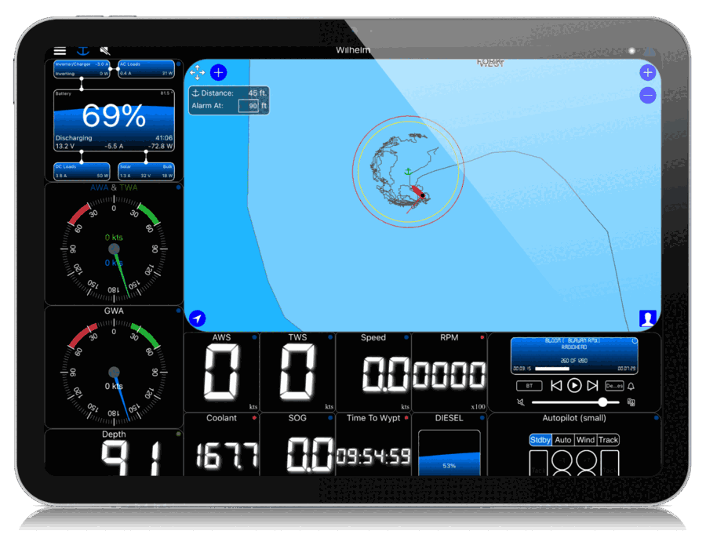

*Image: WilhelmSK App on iPad.*

## Prerequisites

- SignalK server installed, for example on a Victron GX device or RaspberryPi. See Installation for details.
- [WilhelmSK iOS App](https://itunes.apple.com/us/app/wilhelmsk/id1150499484?mt=8)

For use with other Apps (Android, web apps, etc) see Alternatives to WilhelmSK.

## Configuration

**Step 1.** Configure the Vessel data in SignalK server:

[figure not shown]

Be sure to set:

- Boat length
- GPS Distance from Bow
- GPS Distance from Center.

#### Step 2. Install required Signal K Server plugins:

- Open the Signal K Admin UI and if necessary *Login*
- Select *Appstore -> Available* from the menu
- Under *Available Apps* select *All* from the dropdown

[figure not shown]

Locate and install each of the following plugins:

- **signalk-anchoralarm-plugin**
- **signalk-push-notifications**
- **signalk-alarm-silencer**
- **@signalk/tracks-plugin**

After installation is complete, restart the server.

*Note: The _Restart* button only appears at the upper right of the screen when security has been enabled. (See Enabling Security for details.)_

#### Step 3 Configure the plugins:

Each of the plugins you installed in the previous step need to be configured and enabled. To do this:

- Select `Server -> Plugin Config`` from the menu
- Locate the plugin
- Set the appropriate configuration values
- Click *Submit*.
- Ensure the plugin is *Enabled*.

Following are details of how to configure each plugin:

*Anchor Alarm plugin:*

This plugin only needs to be enabled.

No configuration is required as the settings values are populated by WilhelmSK.

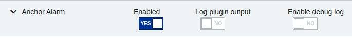

*Alarm Silencer plugin:*

This plugin only needs to be enabled.

No configuration options available.

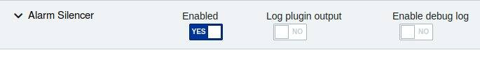

*Push Notifications plugin:*

- To send notifications via an Internet connection check *Enable Remote Push*.

*Note: The WilhelmSK app uses an Amazon RDS service to deliver push notifications. No additional accounts, etc are required as they are included with purchase.*

- *Local Push SSIDs*: Enter the SSID(s) of the WiFi network(s) on your boat which the devices that are to receive notifications are connected.
- *Local Push Port* specifies the port number that WilhelmSK app will receive the local push notifications. The default value is *3001* and only needs to be changed if that port number is already in use by another app / plugin on the Signal K Server.

*Note: It is not necessary to set the same value in the WilhelmSK app, it auto configures itself.*

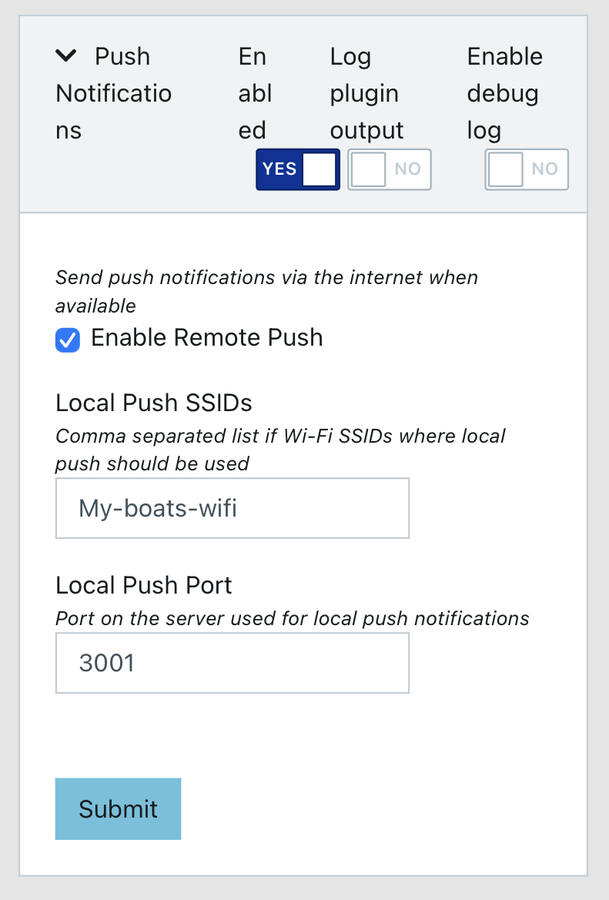

*Tracks plugin*

This plugin keeps track of the position of vessels visible to the Signal K Server. This enables apps to display a track of vessel movements.

The configuration values chosen will determince the amount of resource required run the plugin (and potentially the performance of the Signal K Server) so please consider this when making entries.

The following settings represent conservative values that are suitable for use with an anchor alarm:

*Note: This plugin stores the track all the time, not only when on anchor. Which comes in handy when you enable the the anchor alarm a while after having dropped the anchor.*

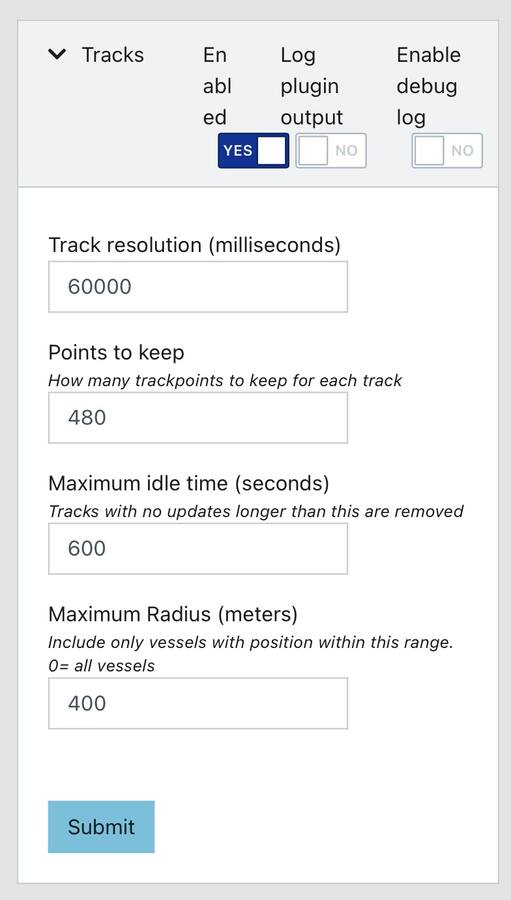

*Step 4.* Connect WilhelmSK to your SignalK server

After installing the WilhelmSK app, go to the iOS settings screen and check that it has network access permissions.

[figure not shown]

Also ensure that Background App Refresh also enabled as it is required for local push notifications and to raise an alarm while WilhelmSK app in not open on your phone or tablet.

Once network access has been enabled, start the WilhelmSK app and go to the connections menu.

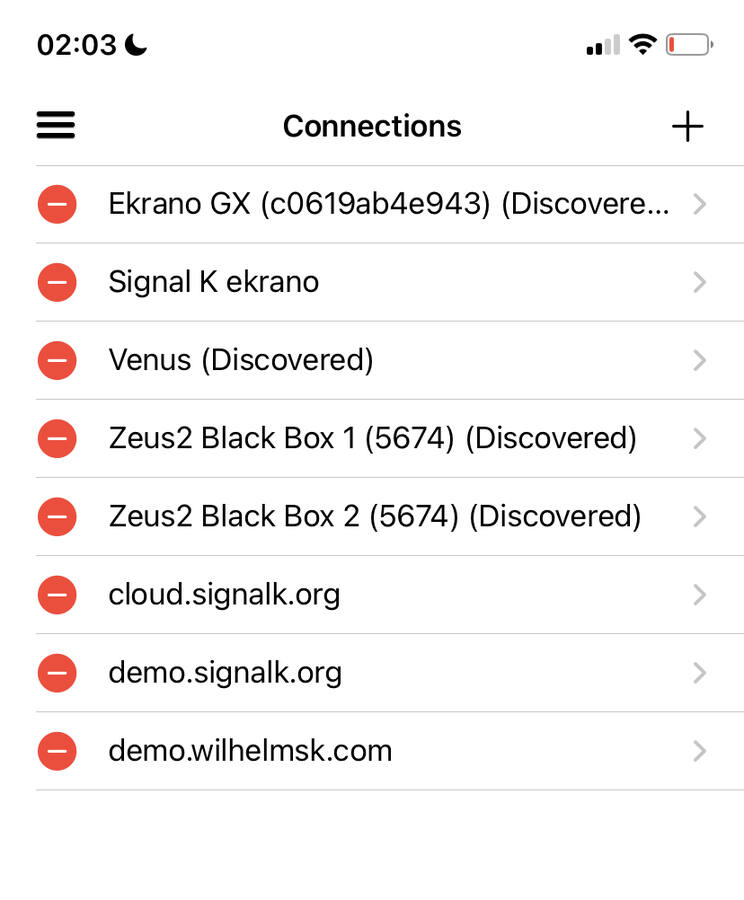

Your boat's name *(as entered in the vessel data, in step 1 above)* and suffixed with (Discovered) should appear in the list. *(If you can’t see it please ensure WilhelmSK has been granted network access permissions.)*

Select your boat from the list and the configuration screen is displayed:

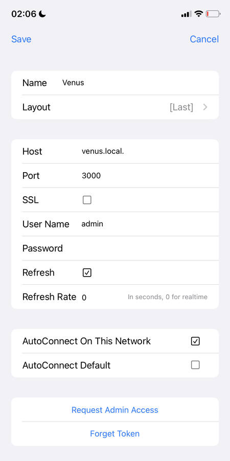

- Enter the user name and password that you use when logging into Signal K Server.
- Select *AutoConnect On This Network*. This will cause WilhelmSK to auto-select this connection when on the currently connected WiFi network.

With regards to the other available config options:

- *Request Admin Access* provides an alternative to using user name and password using a security token instead. Selecting this option sends an Access Request to the SignalK Server. The request will then need to be approved in the *Security -> Access Requests* screen of the Signal K Admin UI .
- *Port*: 3000 is the standard port.
- *AutoConnect Default* is used for a remote connection, which is out of scope of this manual.

Finally, verify your connection. Swipe left to back to the main menu and select the same connection:

[figure not shown]

*Step 5.* Enable WilhelmSK to receive push notifications

From the *Settings* menu select *Notifications*.

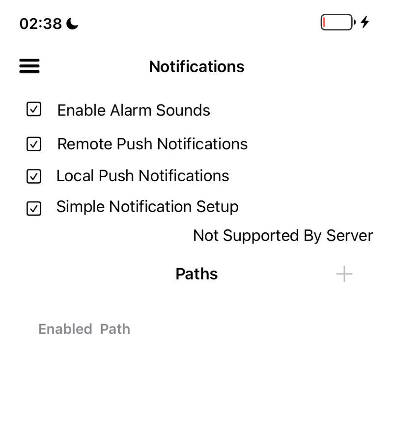

Note that the actual monitoring of the GPS coordinates is done by Signal K Server itself, not the WilhelmSK app. The app is only used to configure the anchor location, enable the alarm and to receive the alarm notifications.

It is also possible, and highly recommended, to add other notifications. For example via Fusion stereo, if installed, or by using a dry contact with audible alarm. *(These are out of scope of this manual.)*

*Tip: For using the Fusion stereo: search the server plugins with the keyword Fusion.*

## Using the Anchor Alarm

Now that the connections have been configured, go to the main screen of the WilhelmSK App where you’ll see something similar to the following screenshot.

If data is being received from the Signal K server, green dots are displayed in the top right of each gauge to indicate that the value displayed is current.

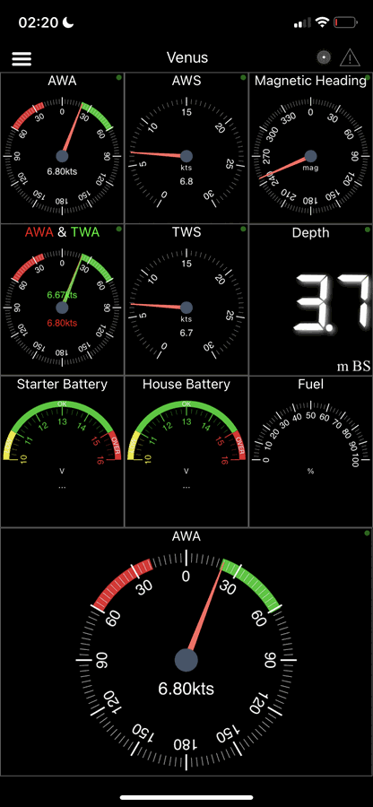

In case of incorrect username and/or password or other connection errors, these will be displayed at the top of the screen as warning.

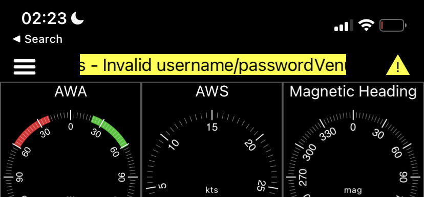

With an established connection and data being received, swipe to the right a few times to display the anchor watch page.

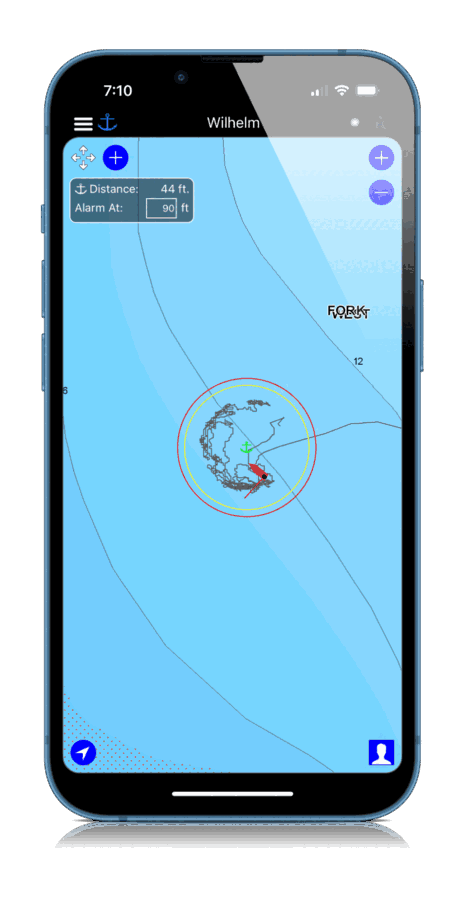

Clicking the anchor on the top left of screen (next to the menu button), cycles through the sequence of arming / disarming the alarm:

- White anchor indicates disarmed. Click when dropping the anchor and the color will change to yellow.
- Yellow anchor indicates that the rode length is being calculated. Click when you have finished letting out the anchor and the colour will change to green.
- Green anchor means the alarm is armed and ready.

Use the “four arrows icon” on the top left of screen to move the anchor location.

You can also change the alarm radius.

Clicking the green anchor will prompt you to confirm that you want to disarm the alarm / raise the anchor.

*TIP: To return to other pages (i.e. COG and AWA gauges) swipe left by holding the Course up/Head up/North up menu.*

## Alarms & Notifications

For most use cases, push notifications shouldn’t be the only means of receiving alarms as the phone can decide to hide notifications, etc so additional means of sounding the alarm should be employed.

Following are some alternatives.

### Audible alarms using the Raspberry Pi audio connector

To have the Signal K Server produce audible notifications using a speaker connected directly to the Raspberry Pi audio connector install the signalk-audio-notifications plugin.

### Alarm to NMEA2000 network

To have the Signal K Server forward the alarm to the NMEA2000 network to appear on connected devices, install and configure the signalk-to-nmea2000 plugin.

#### Raymarine alarm compatibility

With the Raymarine options enabled in the *signalk-to-nmea2000* plugin, an audible alarm will be generated on the Raymarine SeaTalkNG Auxiliary Alarm Buzzer - A8061 and will display on Raymarine Axiom plotters.

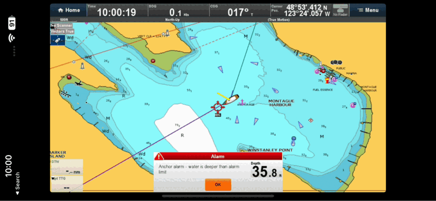

#### Garmin alarm compatibility

Compatible

#### Navico (B&G, Simrad, Lowrance) alarm compatibility

Not compatible

#### Yacht Devices compatibility

The [YDAB-01](https://www.yachtd.com/products/alarm_button.html) is a very flexible and configurable device sold by Yacht Devices.

It is connected to the NMEA2000 network and has a 10W audio amplifier which can output sound via a 4 or 8 Ohm speaker which directly connected. It has bank of 28 sound signals can be configured to sound on receipt of the anchor alarm.

#### Additional information

The following post on Panbo is a great resource with regards to the N2K Alert PGNs: [Link](https://panbo.com/nmea-2000-network-alert-pgns-seem-great-so-why-are-they-hardly-used/)

### Remote notifications

There are a number of Signal K Server plugins which enable notifications to be sent remotely, following are just a few:

#### signalk-pushover-notification-relay

This plugin listens for a change of state in Signal K notifications and sends the updates to the Pushover App which is available for both Apple and Android phones and tablets.

This is a paid service from [Pushover](https://pushover.net/).

*Plugin:* signalk-pushover-notification-relay

#### signalk-notifications-manager

This plugin also works with [Pushover](https://pushover.net/) to deliver notifications as push messages on your phone or tablet, but it also:

- Keeps a history of alerts stored in a local database
- Includes a Signal K web app to manage the notifications.

*Plugin:* [signalk-notifications-manager](https://www.npmjs.com/package/signalk-notifications)

#### signalk-clicksend-notifications-relay

This plugin forwards notifications via the (paid) Clicksend SMS gateway, which can deliver notifications to your phone.

*Plugin:* [signalk-clicksend-notifications-relay](https://www.npmjs.com/package/signalk-clicksend-notification-relay)

### Switching a relay

Operating a switch or relay provides a range of options for sounding an alarm but will require diving a bit deeper into the various (and extensive) automation options made available by Signal K Server.

A good place to start is the signalk-switch-automation plugin.

## Alternatives to WilhelmSK

As the data processing to "watch" the anchor and generate the alarm messages is performed by the Signal K Server, client applications, any client application that supports the *anchor-alarm* plugin can be used to arm / disarm and configure it.

Listed below are some other apps and supported operations:

| Client App | Arm / disarm | Set radius | Move location | See track | Plays sound |
| --- | --- | --- | --- | --- | --- |
| **Wilhelm SK** (iOS) | yes | yes | yes | yes | yes |
| **Anchor alarm plugin** (web app) | yes | yes | yes | yes | no |
| **Freeboard SK** (web app) | yes | yes | yes | yes | yes |
| **Aqua Map** (iOS & Android) | ? | ? | ? | ? | ? |

### Anchor Alarm Plugin

The anchor alarm plugin provides a web user interface available under *WebApps* in the Signal K Server Admin UI.

It provides the ability to arm / disarm, set the radius and shift the anchor but does not display the alarm on screen or play a sound.

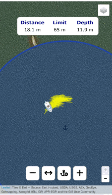

### Freeboard SK

Freeboard SK provides a "sequence" driven user interface to "step" through the setting of the anchor alarm.

It provides the ability to drop / raise the anchor, set / adjust the alarm radius and shift the anchor position via the *Anchor Watch* feature in the main menu.

When set, it will:

- Display the alarm radius on the map
- Show the vessel track whilst anchored

When alarm is triggered:

- Display an alarm notification on screen
- Play a sound

It is available under *WebApps* in the Signal K Server Admin UI.

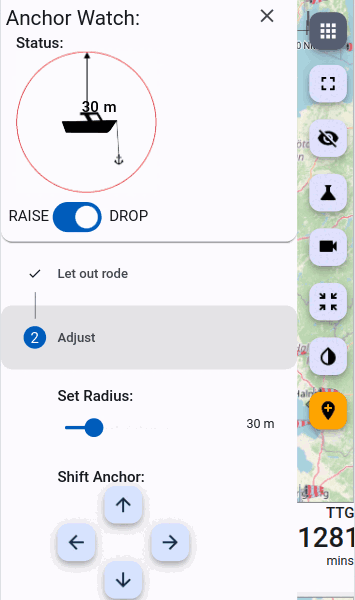

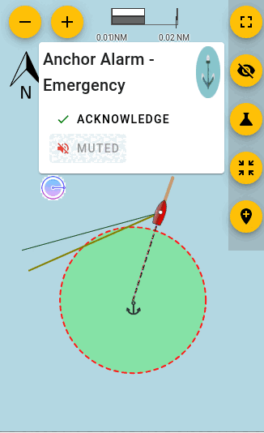

# Data Logging

Signal K server can log all input data from the configured input connections into hourly data log files.

You can activate data logging for each connection by switching on Data Logging under Server / Data Connections, saving the connection settings. The setting takes effect after restarting the server.

The log files are downloadable in the Admin UI under Server / Server Logs.

The logs contain the data that the server has processed in the raw, original format (prior to conversion to Signal K) and each message is timestamped.

Log files can be used for archiving, to later play back the data or for debugging purposes. The server can play them back by creating a Data Connection with Data Type `File Stream` and secondary Data Type as `Multiplexed Log`.

# Signal K Server as a NMEA0183 Data Server

This document details how to setup Signal K Server to read AIS and navigation data from a NMEA2000 (or any other) network and make it available on a WiFi network for use with popular phone / tablet apps like:

- Navionics
- iSailor
- iNavX
- Aqua Map
- WilhelmSK.

The Signal K Server does this by passing the data received from the configured Data Connections, through two plugins which transform it to NMEA0183 sentences, which are then transmitted on the WiFi network.

## Prerequisites

A Signal K Server:

- Installed on a suitable device (e.g. Victron GX, RaspberryPi, etc). *See Installation for details.*
- Connected to a NMEA2000, etc network and Data Connections configured.
- Connected to a WiFi network. *(Beyond the scope of this document.)*

## Server Setup and Configuration

All configuration is done from within the Signal K Server Admin UI. Open the Admin UI in your browser and complete the following steps.

#### *Step 1.* Enter Vessel Base Data:

[figure not shown]

#### *Step 2.* Install and Configure Plugins:

The following plugins are required to process and transform the received data to NMEA0183:

- `signalk-to-nmea0183` ([documentation](https://www.npmjs.com/package/@signalk/signalk-to-nmea0183) on npmjs)
- `signalk-n2kais-to-nmea0183` ([documentation](https://www.npmjs.com/package/signalk-n2kais-to-nmea0183) on npmjs)

*Note: Starting with Signal K Server version 2.2.0 these plugins are pre-installed. It is recommended that these plugins be updated to the current version.*

**To install the plugins:**

- In the Admin UI, select *Appstore -> Available-> All* from the menu
- Locate the `signalk-to-nmea0183`plugin and click the install icon
- Locate the `signalk-n2kais-to-nmea0183` plugin and click the install icon
- Restart the Signal K Server.

*Note: If the **Restart** button is not displayed in the upper right of screen, refer to Enabling Security for details.*

**To configure the plugins:**

- In the Admin UI, select *Server -> Plugin Config* from the menu.
- Locate `signalk-to-nmea0183` plugin.
  1. Ensure it is enabled
  2. Check ALL the boxes to transmit all NMEA0183 sentence types
  3. Leave the transmission interval (throttle) at 0
  4. Click the **Submit** button to save your choices.

[figure not shown]

- Locate `signalk-n2kais-to-nmea0183` plugin. This plugin transmits all the AIS targets.
  1. Ensure it is enabled
  2. Enter *nmea0183out* in the **NMEA 0183 Out Events** field.
  3. Click the **Submit** button to save the configuration.

[figure not shown]

#### *Step 3.* Enable NMEA0183 on the WiFi network:

- In the Admin UI, select *Server -> Settings*
- Locate the **Server Settings** section
- Ensure that **NMEA 0183 over TCP (10110)** is set to **On**
- Click **Save** and **Restart** the Signal K Server.

[figure not shown]

Once restarted the Signal K Server will transmit NMEA0183 sentences containing all your navigation and available AIS target data on the WiFi network on TCP port 10110.

*Note: It is recommended that **Signal K over TCP (8375)** is set to **On** if you are using an app (e.g. Aqua Map) which supports the “Signal K over TCP” protocol as it is more feature rich.*

## Configuring Apps

Device apps can now be configured to connect to the NMEA0183 data stream from the Signal K Server.

Following is an example of how to connect the Navionics boating app.

- Open the menu
- Select **Paired devices** and add a new paired device
- Enter a name for the device *e.g. MySignalK Server*
- In **Host** enter the IP address of the Signal K Server you configured in the steps above
- In **Port** enter *10110*
- Select **TCP**
- Click **Save**

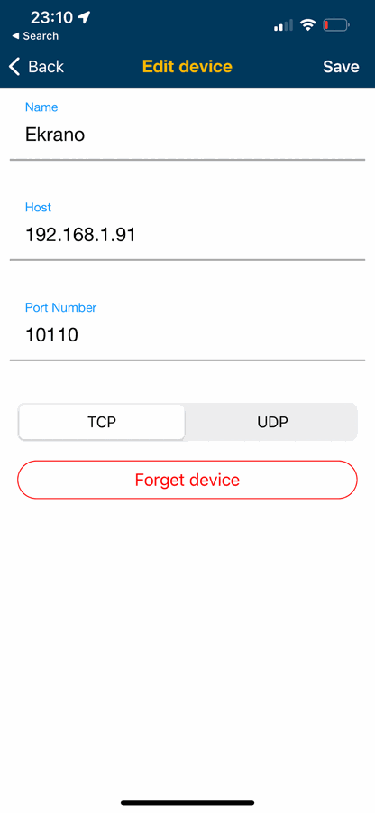

# Linux udev Rules

Linux assigns device names sequentially to hotplug hardware. Usually, your device will get the same name each time you connect it or boot your computer, but sometimes the name may change. For this reason, disks and partitions are typically referenced by UUID and not by device path any more. For our purposes dealing with USB serial adapters, the assigned device name is typically `/dev/ttyUSB0`. However, if you have more than adapter the device names may not always be consistent. Therefore, it is a good idea to create a udev rule to provide an alias for your device.

The example below assumes Debian or Ubuntu as the distribution, but it should be similar for others.

First, we need to collect some identifiers for the device we want to alias. In a shell, run the `usb-devices` command.

```bash
$ usb-devices
```

This will enumerate all of the USB devices connected to your computer (including internal USB hubs). In our example, we're looking for Actisense devices. Write down the `Vendor`, `ProdId` and `SerialNumber` values for each of your devices.

Then, in your favorite text editor, create a file in `/etc/udev/rules.d/` called `90-actisense.rules`. The 90 ensures that it processed after other udev rules.

The contents of the file should be:

```
SUBSYSTEMS=="usb", ATTRS{idVendor}=="0403", ATTRS{idProduct}=="d9aa", ATTRS{serial}=="1B091", SYMLINK+="actisense"
```

Replace `0403` with the value you wrote down for `Vendor` (if you are working with and Actisense device, it will likely be the same). Replace `d9aa` with the value you wrote down for `ProdId` and replace `1B091` with the value you wrote down for `SerialNumber`. The last change is to give your symlink a name. In the example above it is `actisense`, but you can call it whatever you want (without spaces or filesystems-reserved characters like `/`). Let's say you have two USG-1 devices, one for the autopilot and one for your VHF radio. You might want to name these devices `autopilot` and `vhf`. Then they would be available at `/dev/autopilot` and `/dev/vhf` respectively.

You can specify multiple rules in one file, one rule per line:

```
SUBSYSTEMS=="usb", ATTRS{idVendor}=="0403", ATTRS{idProduct}=="d9aa", ATTRS{serial}=="1B091", SYMLINK+="autopilot"
SUBSYSTEMS=="usb", ATTRS{idVendor}=="0403", ATTRS{idProduct}=="d9aa", ATTRS{serial}=="1B094", SYMLINK+="vhf"
```

After creating this file, disconnect your devices and plug them back in. You should see the new entries under `/dev`. If not, reboot.

# Unit Preferences

This guide describes the unit preferences mechanism in Signal K Server.

## For End Users

Signal K Server allows you to define your preferred units for different categories of data (e.g., Speed, Depth, Temperature) centrally. These settings are applied across all compatible apps and dashboards.

### Changing Unit Settings

You can configure your unit preferences in the Signal K Server Admin UI.

1. Open the **Server Admin** interface.
2. Navigate to **Server > Configuration > Settings**.
3. Scroll down to the **Unit Preferences** section.

### Available Settings

#### Active Preset

The simplest way to configure units is to select a **Preset**. A preset is a collection of unit preferences for all standard categories.

Available presets:

- **Metric**: km/h, kilometers, meters, Celsius, liters.
- **Imperial (US)**: mph, miles, feet, Fahrenheit, US gallons.
- **Imperial (UK)**: mph, miles, feet, Celsius, UK gallons.
- **Nautical (Metric)**: knots, nautical miles, meters, Celsius, liters.
- **Nautical Imperial (US)**: knots, nautical miles, feet, Fahrenheit, US gallons.
- **Nautical Imperial (UK)**: knots, nautical miles, feet, Celsius, UK gallons.

#### Per-User Settings

Preferences are stored **per user**. If you log in with your user account, your unit settings will follow you across different devices. If no user is logged in (or for anonymous users), the server's global default preset (configured by the administrator) is used.

#### Custom Presets

Advanced users can upload **Custom Presets** to define specific combinations of units that aren't covered by the built-in options.

### Overriding Specific Paths

In addition to category-wide settings (e.g., "All speeds in Knots"), you can override units for specific data paths. For example, you might want *Boat Speed* in Knots but *Wind Speed* in Meters/Second.

An override is specific to a single path and is set under **Data → Metadata**. The override can specify either just the category for the path or directly the target unit. An override that names no target unit of its own follows the active preset's target unit choice for its category. An override that specifies the target unit takes precedence over the preset's setting for the category.

## Unit Categories

Unit categories are the mechanism that allows the server to apply unit preferences to a wide range of data paths without needing configuration for every single path.

### How Categories Work

1. **Categorization**: Every numeric Signal K path is assigned to a **Category** (e.g., `speed`, `temperature`, `depth`). This assignment is defined in the server's default configuration but can be customized.
2. **Base Unit**: The category defines the **Base Unit** (usually the SI unit) that the raw data is expected to be in. For example, the `speed` category expects `m/s`.
3. **Target Unit**: Your active Preset defines a **Target Unit** for each category. For example, your preset might map the `speed` category to `kn` (knots).
4. **Conversion**: When data is requested, the server looks up the path's category, finds the target unit from your preset, and provides the conversion formula.

This system means that if you set your `speed` preference to Knots, it applies to *Boat Speeds*, *Wind Speeds* and any other path assigned to the `speed` category.

### Standard Categories

Additional categories include `dateTime`, `epoch` for time representations, and `unitless`/`boolean` for data that doesn't require conversion.

## For Client Application Developers

The Unit Preferences system simplifies client development by managing unit preferences centrally, on the server across all unit preferences aware client applications. As a developer, you don't need to maintain user preference settings in your application and can use the settings and conversion formulas provided by the server.

### How it Works

When you fetch metadata for a path (e.g., `vessels.self.navigation.speedOverGround`), the server checks the active unit preferences and includes a `displayUnits` object in the meta data.

### REST API Usage

Request the metadata for any path:

`GET /signalk/v1/api/vessels/self/navigation/speedOverGround/meta`

**Response Example:**

```json
{
  "units": "m/s",
  "description": "Speed over ground",
  "displayName": "SOG",
  "displayUnits": {
    "category": "speed",
    "targetUnit": "kn",
    "formula": "value * 1.94384",
    "inverseFormula": "value / 1.94384",
    "symbol": "kn",
    "displayFormat": "0.0"
  }
}
```

The `displayUnits` object provides everything you need to display the value:

- **category**: The unit category this path belongs to (e.g., "speed", "depth", "temperature").
- **targetUnit**: The unit the user wants to see (e.g., "kn" for knots).
- **formula**: A [Math.js](https://mathjs.org/) expression to convert the raw SI value to the target unit. The variable `value` represents the input.
- **inverseFormula**: A Math.js expression to convert back from the display unit to SI (useful for user input).
- **symbol**: The symbol to display next to the value.
- **displayFormat**: (Optional) A format pattern for consistency (e.g., "0.0" for one decimal place).

### Asking for Path-Specific Overrides

A resolved response reads the same whether the target unit comes from a path-specific override or from the applied preset. An editor has to tell the two apart, so it asks for the answer with `displayUnitsOverride=true`:

`GET /signalk/v1/api/vessels/self/navigation/speedOverGround/meta?displayUnitsOverride=true`

The response then carries one more field in `displayUnits`:

- **override**: Path-specific unit override, as `targetUnit` and `displayFormat`. Empty when the path follows the preset.

The same parameter works on the WebSocket stream URL, next to `sendMeta=all`:

`ws://localhost:3000/signalk/v1/stream?subscribe=none&sendMeta=all&displayUnitsOverride=true`

Display code needs none of this, so the field is absent unless it is asked for.

A metadata `PUT` reads `override` even when the request did not ask for one, so saving a resolved response back does not turn the preset's current settings into a path-specific override. The metadata delta a `PUT` triggers carries the field as well.

### WebSocket Stream

When subscribing to the WebSocket stream, add `sendMeta=all` to receive metadata once for each path (sent with the first delta for that path, and again only if it changes):

```javascript
const ws = new WebSocket('ws://localhost:3000/signalk/v1/stream?subscribe=none')

ws.onopen = () => {
  ws.send(
    JSON.stringify({
      context: 'vessels.self',
      subscribe: [
        {
          path: 'navigation.speedOverGround',
          policy: 'instant',
          sendMeta: 'all'
        }
      ]
    })
  )
}
```

**Delta with Metadata:**

```json
{
  "context": "vessels.urn:mrn:signalk:uuid:...",
  "updates": [
    {
      "values": [
        {
          "path": "navigation.speedOverGround",
          "value": 5.14,
          "meta": {
            "units": "m/s",
            "description": "Speed over ground",
            "displayUnits": {
              "category": "speed",
              "targetUnit": "kn",
              "formula": "value * 1.94384",
              "inverseFormula": "value / 1.94384",
              "symbol": "kn",
              "displayFormat": "0.0"
            }
          }
        }
      ]
    }
  ]
}
```

Using `sendMeta=all` eliminates the need for separate REST calls to fetch metadata.

### Consuming Data

1. **Get the value and metadata** - Either subscribe to the WebSocket stream with `sendMeta=all` (recommended), or poll the REST API and fetch metadata separately.
2. **Check for `displayUnits`** - If present, the user has unit preferences configured.
3. **Convert the value** - Evaluate the `formula` expression with the SI value as `value`.
4. **Display the result** - Show the converted value with the provided `symbol` and `displayFormat`.

This ensures that if the user changes their preferences (e.g., from "Knots" to "m/s" or "km/h") on the server, your application automatically reflects those changes without any code updates.

### API Endpoints

The unit preferences system exposes the following REST API endpoints:

| Method | Endpoint | Description |
| --- | --- | --- |
| GET | `/signalk/v1/unitpreferences/config` | Get the current configuration |
| PUT | `/signalk/v1/unitpreferences/config` | Update the configuration |
| GET | `/signalk/v1/unitpreferences/categories` | Get all unit categories (merged standard + custom) |
| GET | `/signalk/v1/unitpreferences/definitions` | Get all unit definitions (merged standard + custom) |
| GET | `/signalk/v1/unitpreferences/custom-definitions` | Get custom unit definitions only |
| PUT | `/signalk/v1/unitpreferences/custom-definitions` | Update custom unit definitions |
| GET | `/signalk/v1/unitpreferences/custom-categories` | Get custom category mappings only |
| PUT | `/signalk/v1/unitpreferences/custom-categories` | Update custom category mappings |
| GET | `/signalk/v1/unitpreferences/presets` | List all available presets (built-in and custom) |
| GET | `/signalk/v1/unitpreferences/presets/:name` | Get a specific preset by name |
| PUT | `/signalk/v1/unitpreferences/presets/custom/:name` | Create or update a custom preset |
| DELETE | `/signalk/v1/unitpreferences/presets/custom/:name` | Delete a custom preset |
| GET | `/signalk/v1/unitpreferences/active` | Get the currently active preset |
| GET | `/signalk/v1/unitpreferences/default-categories` | Get the default category mappings |

# Help & Support

Signal K has an friendly and helpful community where you can find support and assistance whether you are trouble shooting issues or just have a question.

**Join the discussion:**

- [**Discord**](https://discord.com/channels/1170433917761892493/1170433918592368684) *(New to Signal K Discord? [Click here](https://discord.gg/uuZrwz4dCS) for an invite.)*
- [**GitHub Discussions**](https://github.com/SignalK/signalk/discussions/)

## Frequently Asked Questions

Answers to common issues and queries can be found on the [Frequently Asked Questions](https://github.com/SignalK/signalk-server/wiki/FAQ:-Frequently-Asked-Questions) space on GitHub.

Here are some common queries:

- [How do I integrate with NMEA2000 (CAN bus)](https://github.com/SignalK/signalk-server/wiki/FAQ:-Frequently-Asked-Questions#how-do-i-integrate-with-nmea2000-can-bus).
- [Installing & Updating NodeJS](https://github.com/SignalK/signalk-server/wiki/Installing-and-Updating-Node.js)

## Troubleshooting

### "Network congestion detected" - What does this mean?

Your device's connection to the Signal K server is slower than the data being sent. This can happen when:

- **WiFi signal is weak** - try moving closer to your access point
- **Network is busy** - other devices streaming video, large downloads, etc.
- **Slow mobile connection** - cellular data may not keep up with high-frequency updates
- **Many sensors active** - the server is sending a lot of data

**What happens?**

When your connection can't keep up:

1. The server keeps only the **most recent value** for each data point
2. You still see **current, accurate values** - they're just not every single update
3. The system **recovers automatically** when your connection improves

This is normal and safe. Your navigation data remains accurate - you just might miss seeing some intermediate values (like every single GPS position update during a slow period).

**What can I do?**

- Move closer to your WiFi access point
- Check if other devices are using a lot of bandwidth
- If on a boat, verify the network connection to your navigation computer
- Consider using a wired Ethernet connection for critical displays
- For remote access (4G, VPN, public internet): enable WebSocket compression in Admin UI → Server → Settings to reduce bandwidth usage